# Practical study of a basic genetic algorithm on the Knapsack problem

David Mora Garrido

2024-01-03

```r
library(dplyr)
```

```r
library(ggplot2)
library(corrplot)
```

# Introduction

First we load the results `.csv` file:

```r
df <- read.csv('./results/mknap1.csv')
head(df)
```

|  | problem_index | population_size | crossover_probability | mutation_probability | search_optimal | max_steps | optimal_fitness | optimal_percentage | best_fitness_last_pop | avg_fitness_last_pop | shannon_entropy | num_evaluations | execution_time |
| --- | --- | --- | --- | --- | --- | --- | --- | --- | --- | --- | --- | --- | --- |
| 1 | 2 | 100 | 0.6 | 0.06666667 | false | 1000 | 4015 | 100 | 4015 | 3976.20 | 0.3526604 | 1100 | 0.004 |
| 2 | 2 | 100 | 0.6 | 0.06666667 | false | 1000 | 4015 | 100 | 4015 | 3986.85 | 0.3837379 | 1100 | 0.002 |
| 3 | 2 | 100 | 0.6 | 0.06666667 | false | 1000 | 4015 | 100 | 4015 | 3872.84 | 0.4283429 | 1100 | 0.001 |
| 4 | 2 | 100 | 0.6 | 0.06666667 | false | 1000 | 4015 | 100 | 3940 | 3842.70 | 0.3611125 | 1100 | 0.001 |
| 5 | 2 | 100 | 0.6 | 0.06666667 | false | 1000 | 4015 | 100 | 4015 | 3951.20 | 0.2711168 | 1100 | 0.001 |
| 6 | 2 | 100 | 0.6 | 0.06666667 | false | 1000 | 4015 | 100 | 4015 | 3912.95 | 0.3808730 | 1100 | 0.001 |

```r
str(df)
```

```
## 'data.frame':    6521 obs. of  13 variables:
##  $ problem_index        : int  2 2 2 2 2 2 2 2 2 2 ...
##  $ population_size      : int  100 100 100 100 100 100 100 100 100 100 ...
##  $ crossover_probability: num  0.6 0.6 0.6 0.6 0.6 0.6 0.6 0.6 0.6 0.6 ...
##  $ mutation_probability : num  0.0667 0.0667 0.0667 0.0667 0.0667 ...
##  $ search_optimal       : chr  "false" "false" "false" "false" ...
##  $ max_steps            : int  1000 1000 1000 1000 1000 1000 1000 1000 1000 1000 ...
##  $ optimal_fitness      : num  4015 4015 4015 4015 4015 ...
##  $ optimal_percentage   : num  100 100 100 100 100 100 100 100 100 100 ...
##  $ best_fitness_last_pop: num  4015 4015 4015 3940 4015 ...
##  $ avg_fitness_last_pop : num  3976 3987 3873 3843 3951 ...
##  $ shannon_entropy      : num  0.353 0.384 0.428 0.361 0.271 ...
##  $ num_evaluations      : int  1100 1100 1100 1100 1100 1100 1100 1100 1100 1100 ...
##  $ execution_time       : num  0.004 0.002 0.001 0.001 0.001 0.001 0.001 0.001 0 0.001 ...
```

We can see that the `search_optimal` column is loaded as string values, so we will convert it to boolean and then integer:

```r
df$search_optimal <- as.integer(as.logical(df$search_optimal))
```

# Study 1: fixed number of evaluations

```r
df_study1 <- filter(df, search_optimal == 0)
str(df_study1)
```

```
## 'data.frame':    2250 obs. of  13 variables:
##  $ problem_index        : int  2 2 2 2 2 2 2 2 2 2 ...
##  $ population_size      : int  100 100 100 100 100 100 100 100 100 100 ...
##  $ crossover_probability: num  0.6 0.6 0.6 0.6 0.6 0.6 0.6 0.6 0.6 0.6 ...
##  $ mutation_probability : num  0.0667 0.0667 0.0667 0.0667 0.0667 ...
##  $ search_optimal       : int  0 0 0 0 0 0 0 0 0 0 ...
##  $ max_steps            : int  1000 1000 1000 1000 1000 1000 1000 1000 1000 1000 ...
##  $ optimal_fitness      : num  4015 4015 4015 4015 4015 ...
##  $ optimal_percentage   : num  100 100 100 100 100 100 100 100 100 100 ...
##  $ best_fitness_last_pop: num  4015 4015 4015 3940 4015 ...
##  $ avg_fitness_last_pop : num  3976 3987 3873 3843 3951 ...
##  $ shannon_entropy      : num  0.353 0.384 0.428 0.361 0.271 ...
##  $ num_evaluations      : int  1100 1100 1100 1100 1100 1100 1100 1100 1100 1100 ...
##  $ execution_time       : num  0.004 0.002 0.001 0.001 0.001 0.001 0.001 0.001 0 0.001 ...
```

## Small problem size

The (relatively) small problem is the third one in the mknap1.txt file, which can be downloaded [here](http://people.brunel.ac.uk/~mastjjb/jeb/orlib/files/mknap1.txt). It is an instance with 15 items and 10 knapsacks or constraints. The argument that we pass to the executable or `.jar` to indicate which problem we want to execute the algorithm against is the index starting from 0, so in this case is ‘2’:

```r
df_study1_small <- filter(df_study1, problem_index == 2)
str(df_study1_small)
```

```
## 'data.frame':    750 obs. of  13 variables:
##  $ problem_index        : int  2 2 2 2 2 2 2 2 2 2 ...
##  $ population_size      : int  100 100 100 100 100 100 100 100 100 100 ...
##  $ crossover_probability: num  0.6 0.6 0.6 0.6 0.6 0.6 0.6 0.6 0.6 0.6 ...
##  $ mutation_probability : num  0.0667 0.0667 0.0667 0.0667 0.0667 ...
##  $ search_optimal       : int  0 0 0 0 0 0 0 0 0 0 ...
##  $ max_steps            : int  1000 1000 1000 1000 1000 1000 1000 1000 1000 1000 ...
##  $ optimal_fitness      : num  4015 4015 4015 4015 4015 ...
##  $ optimal_percentage   : num  100 100 100 100 100 100 100 100 100 100 ...
##  $ best_fitness_last_pop: num  4015 4015 4015 3940 4015 ...
##  $ avg_fitness_last_pop : num  3976 3987 3873 3843 3951 ...
##  $ shannon_entropy      : num  0.353 0.384 0.428 0.361 0.271 ...
##  $ num_evaluations      : int  1100 1100 1100 1100 1100 1100 1100 1100 1100 1100 ...
##  $ execution_time       : num  0.004 0.002 0.001 0.001 0.001 0.001 0.001 0.001 0 0.001 ...
```

Once we have filtered the dataframe, we will drop some columns that are not relevant to the study, and only serves us to remind some information about the particular problem instance and which other parameters we set when we executed the algorithm (in addition to those that we have already used for filtering, like `search_optimal` and `problem_index`). Before doing so, we will review them:

```r
columns_to_drop <- c('problem_index', 'population_size', 'search_optimal', 'max_steps', 'optimal_fitness', 'optimal_percentage', 'num_evaluations', 'execution_time')
summary(df_study1_small[, colnames(df_study1_small) %in% columns_to_drop])
```

```
##  problem_index population_size search_optimal   max_steps    optimal_fitness
##  Min.   :2     Min.   :100     Min.   :0      Min.   :1000   Min.   :4015
##  1st Qu.:2     1st Qu.:100     1st Qu.:0      1st Qu.:1000   1st Qu.:4015
##  Median :2     Median :100     Median :0      Median :1000   Median :4015
##  Mean   :2     Mean   :100     Mean   :0      Mean   :1000   Mean   :4015
##  3rd Qu.:2     3rd Qu.:100     3rd Qu.:0      3rd Qu.:1000   3rd Qu.:4015
##  Max.   :2     Max.   :100     Max.   :0      Max.   :1000   Max.   :4015
##  optimal_percentage num_evaluations execution_time
##  Min.   :100        Min.   :1100    Min.   :0.000000
##  1st Qu.:100        1st Qu.:1100    1st Qu.:0.000000
##  Median :100        Median :1100    Median :0.001000
##  Mean   :100        Mean   :1100    Mean   :0.000816
##  3rd Qu.:100        3rd Qu.:1100    3rd Qu.:0.001000
##  Max.   :100        Max.   :1100    Max.   :0.016000
```

```r
ComputeFitnessDeviation <- function(df) {
  df$optimal_deviation_best_last_pop <- (df$optimal_fitness - df$best_fitness_last_pop)/df$optimal_fitness
  print(summary(df$optimal_deviation_best_last_pop))
  return(df)
}
```

```r
df_study1_small <- ComputeFitnessDeviation(df_study1_small)
```

```
##     Min.  1st Qu.   Median     Mean  3rd Qu.     Max.
## 0.000000 0.000000 0.002491 0.006795 0.012453 0.044832
```

Now we can drop the rest of columns:

```r
DropColumns <- function(df, columns_to_drop) {
  df <- df[, !(colnames(df) %in% columns_to_drop)]
  print(colnames(df))
  return(df)
}
```

```r
df_study1_small <- DropColumns(df_study1_small, columns_to_drop)
```

```
## [1] "crossover_probability"           "mutation_probability"
## [3] "best_fitness_last_pop"           "avg_fitness_last_pop"
## [5] "shannon_entropy"                 "optimal_deviation_best_last_pop"
```

Let’s check the correlation between the variables:

```r
corr <- cor(df_study1_small)
corr
```

```
##                                 crossover_probability mutation_probability
## crossover_probability                    1.000000e+00        -2.280213e-19
## mutation_probability                    -2.280213e-19         1.000000e+00
## best_fitness_last_pop                    5.042970e-02        -5.011615e-01
## avg_fitness_last_pop                    -8.481968e-03        -9.637550e-01
## shannon_entropy                          1.787693e-02         8.576903e-01
## optimal_deviation_best_last_pop         -5.042970e-02         5.011615e-01
##                                 best_fitness_last_pop avg_fitness_last_pop
## crossover_probability                       0.0504297         -0.008481968
## mutation_probability                       -0.5011615         -0.963755044
## best_fitness_last_pop                       1.0000000          0.530424097
## avg_fitness_last_pop                        0.5304241          1.000000000
## shannon_entropy                            -0.4220269         -0.905093831
## optimal_deviation_best_last_pop            -1.0000000         -0.530424097
##                                 shannon_entropy optimal_deviation_best_last_pop
## crossover_probability                0.01787693                      -0.0504297
## mutation_probability                 0.85769030                       0.5011615
## best_fitness_last_pop               -0.42202691                      -1.0000000
## avg_fitness_last_pop                -0.90509383                      -0.5304241
## shannon_entropy                      1.00000000                       0.4220269
## optimal_deviation_best_last_pop      0.42202691                       1.0000000
```

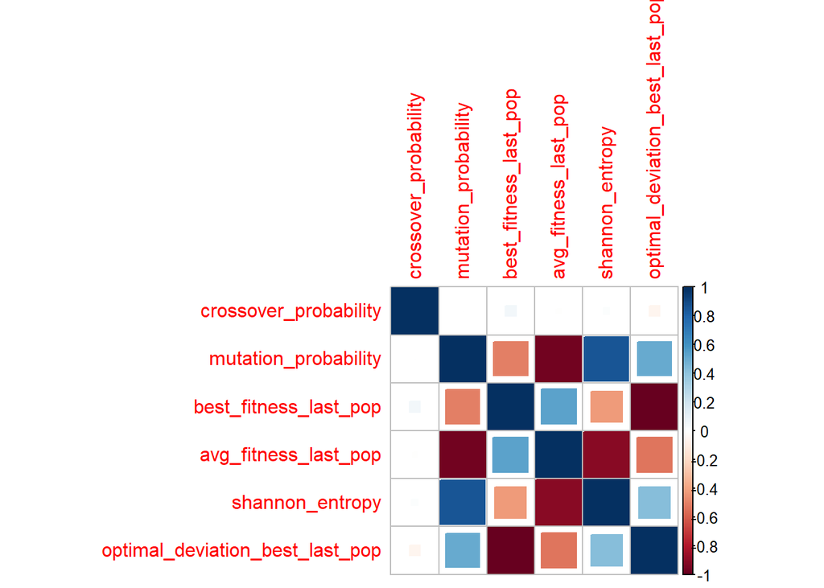

```r
corrplot(corr, method = "square")
```

Now, let’s plot the best fitness in the last population by crossover probability, mutation probability and both:

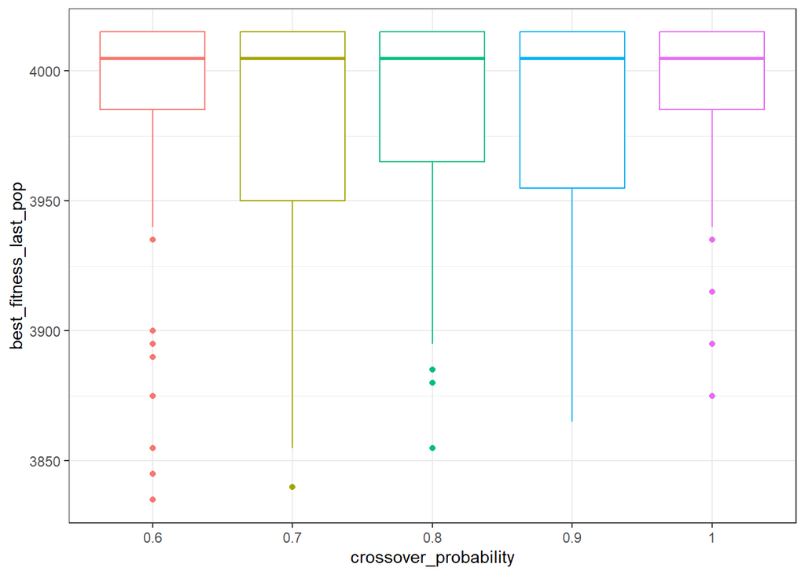

```r
df_study1_small %>%
    mutate(crossover_probability = as.factor(crossover_probability)) %>%
    group_by(crossover_probability) %>%
    ggplot(mapping = aes(x = crossover_probability, y = best_fitness_last_pop, color=crossover_probability)) +
        geom_boxplot() +
        theme_bw() +
        theme(legend.position = "none")
```

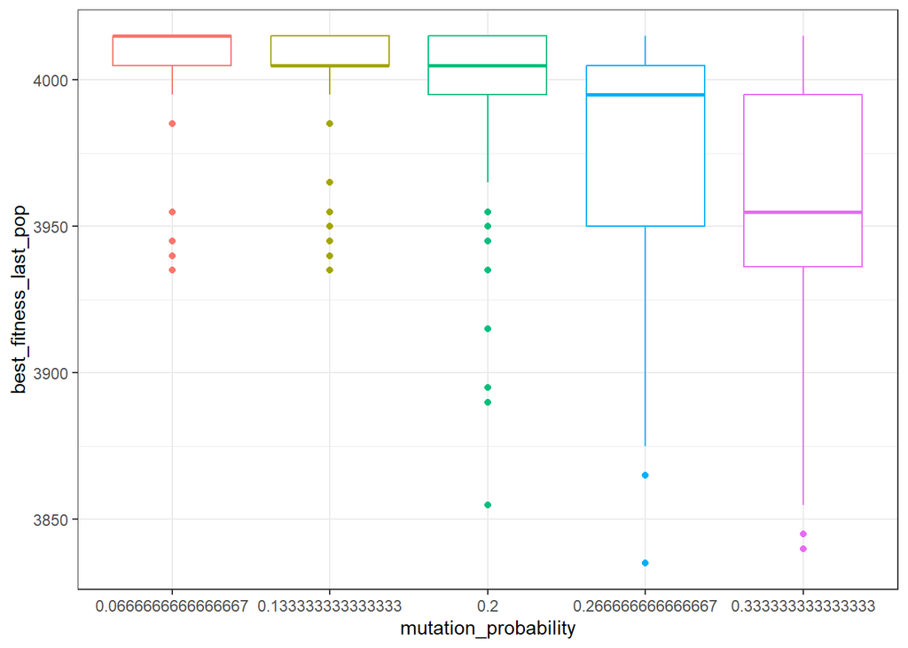

```r
df_study1_small %>%
    mutate(mutation_probability = as.factor(mutation_probability)) %>%
    group_by(mutation_probability) %>%
    ggplot(mapping = aes(x = mutation_probability, y = best_fitness_last_pop, color=mutation_probability)) +
        geom_boxplot() +
        theme_bw() +
        theme(legend.position = "none")
```

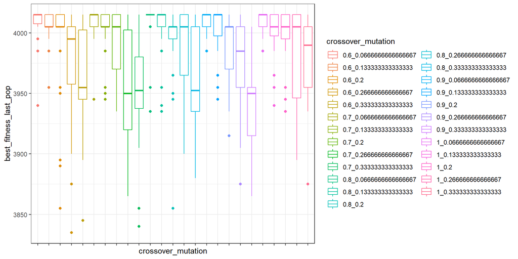

```r
df_study1_small %>%
  group_by(crossover_probability, mutation_probability) %>%
  mutate(crossover_mutation = paste0(crossover_probability, "_", mutation_probability)) %>%
  ggplot(mapping = aes(x = crossover_mutation, y = best_fitness_last_pop, color=crossover_mutation)) +
    geom_boxplot() +
    theme_bw() +
    scale_x_discrete(labels = NULL)
```

Now, we can group by each combination of crossover and mutation probability in order to see the average (best) obtained fitness, its standard deviation and the average deviation from the optimal fitness:

```r
df_study1_small_grouped <- df_study1_small %>%
  mutate(crossover_mutation = paste0(crossover_probability, ",", mutation_probability)) %>%
  group_by(crossover_mutation) %>%
  summarise(
    avg_best_fitness_last_pop = mean(best_fitness_last_pop),
    median_best_fitness_last_pop = median(best_fitness_last_pop),
    std_best_fitness_last_pop = sd(best_fitness_last_pop),
    avg_optimal_deviation_best_last_pop = mean(optimal_deviation_best_last_pop),
    median_optimal_deviation_best_last_pop = median(optimal_deviation_best_last_pop),
    .groups = 'keep'
  )
df_study1_small_grouped <- as.data.frame(df_study1_small_grouped)
df_study1_small_grouped
```

| crossover_mutation | avg_best_fitness_last_pop | median_best_fitness_last_pop | std_best_fitness_last_pop | avg_optimal_deviation_best_last_pop | median_optimal_deviation_best_last_pop |
| --- | --- | --- | --- | --- | --- |
| 0.6,0.0666666666666667 | 4008.167 | 4015.0 | 15.452002 | 0.001701951 | 0.00000000 |
| 0.6,0.133333333333333 | 4005.333 | 4005.0 | 12.726116 | 0.002407638 | 0.00249066 |
| 0.6,0.2 | 3990.833 | 4005.0 | 42.367101 | 0.006019095 | 0.00249066 |
| 0.6,0.266666666666667 | 3976.833 | 3995.0 | 43.874494 | 0.009506019 | 0.00498132 |
| 0.6,0.333333333333333 | 3962.167 | 3955.0 | 42.440289 | 0.013158987 | 0.01494396 |
| 0.7,0.0666666666666667 | 4008.333 | 4015.0 | 13.476246 | 0.001660440 | 0.00000000 |
| 0.7,0.133333333333333 | 4000.333 | 4005.0 | 21.412747 | 0.003652968 | 0.00249066 |
| 0.7,0.2 | 3994.000 | 4005.0 | 26.665230 | 0.005230386 | 0.00249066 |
| 0.7,0.266666666666667 | 3954.667 | 3950.0 | 45.142176 | 0.015026982 | 0.01618929 |
| 0.7,0.333333333333333 | 3950.833 | 3952.5 | 44.684398 | 0.015981735 | 0.01556663 |

[output cut: 15 more lines]

Let’s create a new column with both the crossover and the mutation probability:

```r
df_study1_small <- as.data.frame(df_study1_small %>%
  mutate(crossover_mutation = paste0(crossover_probability, ",", mutation_probability)))
df_study1_small
```

| crossover_probability | mutation_probability | best_fitness_last_pop | avg_fitness_last_pop | shannon_entropy | optimal_deviation_best_last_pop | crossover_mutation |
| --- | --- | --- | --- | --- | --- | --- |
| 0.6 | 0.06666667 | 4015 | 3976.20 | 0.352660385 | 0.00000000 | 0.6,0.0666666666666667 |
| 0.6 | 0.06666667 | 4015 | 3986.85 | 0.383737872 | 0.00000000 | 0.6,0.0666666666666667 |
| 0.6 | 0.06666667 | 4015 | 3872.84 | 0.428342910 | 0.00000000 | 0.6,0.0666666666666667 |
| 0.6 | 0.06666667 | 3940 | 3842.70 | 0.361112548 | 0.01867995 | 0.6,0.0666666666666667 |
| 0.6 | 0.06666667 | 4015 | 3951.20 | 0.271116831 | 0.00000000 | 0.6,0.0666666666666667 |
| 0.6 | 0.06666667 | 4015 | 3912.95 | 0.380872975 | 0.00000000 | 0.6,0.0666666666666667 |
| 0.6 | 0.06666667 | 4005 | 3937.89 | 0.338201141 | 0.00249066 | 0.6,0.0666666666666667 |
| 0.6 | 0.06666667 | 4015 | 3974.25 | 0.335821897 | 0.00000000 | 0.6,0.0666666666666667 |
| 0.6 | 0.06666667 | 4015 | 3971.30 | 0.242870648 | 0.00000000 | 0.6,0.0666666666666667 |
| 0.6 | 0.06666667 | 4015 | 4013.30 | 0.120834038 | 0.00000000 | 0.6,0.0666666666666667 |

[output cut: 740 more lines]

We could employ parametric tests in order to measure with combination of crossover and mutation probabilities (or each one individually) yields better results (we will use the deviation from the optimal fitness for that), but for that we would need to test that the results are approximately normal, or at least not have enough statistical evidence to say otherwise. Thus, let’s apply the Shapiro-Wilk normality test to each combination of parameters:

```r
for (combination in levels(as.factor(df_study1_small$crossover_mutation))) {
  print(combination)
  print(shapiro.test(
    df_study1_small[df_study1_small$crossover_mutation == combination, 'optimal_deviation_best_last_pop']))
}
```

```
## [1] "0.6,0.0666666666666667"
##
##  Shapiro-Wilk normality test
##
## data:  df_study1_small[df_study1_small$crossover_mutation == combination, "optimal_deviation_best_last_pop"]
## W = 0.50817, p-value = 6.545e-09
##
## [1] "0.6,0.133333333333333"
##
##  Shapiro-Wilk normality test
##
## data:  df_study1_small[df_study1_small$crossover_mutation == combination, "optimal_deviation_best_last_pop"]
## W = 0.69397, p-value = 1.276e-06
##
## [1] "0.6,0.2"
##
##  Shapiro-Wilk normality test
##
## data:  df_study1_small[df_study1_small$crossover_mutation == combination, "optimal_deviation_best_last_pop"]
## W = 0.61915, p-value = 1.26e-07
##
## [1] "0.6,0.266666666666667"
##
##  Shapiro-Wilk normality test
##
## data:  df_study1_small[df_study1_small$crossover_mutation == combination, "optimal_deviation_best_last_pop"]
## W = 0.78276, p-value = 3.23e-05
##
## [1] "0.6,0.333333333333333"
##
##  Shapiro-Wilk normality test
##
## data:  df_study1_small[df_study1_small$crossover_mutation == combination, "optimal_deviation_best_last_pop"]
## W = 0.91272, p-value = 0.01744
##
## [1] "0.7,0.0666666666666667"
##
##  Shapiro-Wilk normality test
##
## data:  df_study1_small[df_study1_small$crossover_mutation == combination, "optimal_deviation_best_last_pop"]
```

[output cut: 119 more lines]

```
## W = 0.7173, p-value = 2.813e-06
##
## [1] "1,0.266666666666667"
##
##  Shapiro-Wilk normality test
##
## data:  df_study1_small[df_study1_small$crossover_mutation == combination, "optimal_deviation_best_last_pop"]
## W = 0.80611, p-value = 8.489e-05
##
## [1] "1,0.333333333333333"
##
##  Shapiro-Wilk normality test
##
## data:  df_study1_small[df_study1_small$crossover_mutation == combination, "optimal_deviation_best_last_pop"]
## W = 0.83157, p-value = 0.0002611
```

As we can see, assuming an alpha value of 0.02, there’s enough evidence in most of the tests to say that the samples are not normally distributed (null hypothesis is rejected). Thus, we won’t apply any parametric tests. **We won’t show the normality test anymore as the null hypothesis is always rejected, for all studies and problem sizes that we have executed. We encourage the reader to uncomment the commented cells in nexts sections to verify it.**

```r
kruskal.test(optimal_deviation_best_last_pop ~ crossover_mutation, data = df_study1_small)
```

```
##
##  Kruskal-Wallis rank sum test
##
## data:  optimal_deviation_best_last_pop by crossover_mutation
## Kruskal-Wallis chi-squared = 245.85, df = 24, p-value < 2.2e-16
```

The obtained p-value is smaller than 0.02, so there’s enough statistical evidence to say that at least one of the combination of parameters does not come from the same population or distribution of values for the deviation from the optimal fitness. Thus, we can apply the Wilcoxon test to each pair of combinations with the [Benjamini & Hochberg correction](https://www.statisticshowto.com/benjamini-hochberg-procedure/):

```r
GetNumberDifferentPairs <- function(wilcoxon_test_result, alpha) {
  sprintf("Number of different pairs: %d", length(which(wilcoxon_test_result$p.value < alpha)))
}
```

```r
result <- pairwise.wilcox.test(x = df_study1_small$optimal_deviation_best_last_pop,
                               g = df_study1_small$crossover_mutation,
                               p.adjust.method = "BH",
                               paired = FALSE)
print(result)
```

```
##
##  Pairwise comparisons using Wilcoxon rank sum test with continuity correction
##
## data:  df_study1_small$optimal_deviation_best_last_pop and df_study1_small$crossover_mutation
##
##                        0.6,0.0666666666666667 0.6,0.133333333333333 0.6,0.2
## 0.6,0.133333333333333  0.07993                -                     -
## 0.6,0.2                0.05763                0.79375               -
## 0.6,0.266666666666667  4.4e-05                0.00152               0.02657
## 0.6,0.333333333333333  2.4e-06                2.6e-05               0.00191
## 0.7,0.0666666666666667 0.59717                0.18170               0.16165
## 0.7,0.133333333333333  0.05424                0.74791               0.99373
## 0.7,0.2                0.01688                0.37366               0.71829
## 0.7,0.266666666666667  3.3e-06                3.7e-05               0.00193
## 0.7,0.333333333333333  3.0e-07                9.7e-07               0.00021
## 0.8,0.0666666666666667 0.56209                0.00816               0.00851
## 0.8,0.133333333333333  0.21980                0.64716               0.47590
## 0.8,0.2                0.00186                0.07710               0.22202
## 0.8,0.266666666666667  0.00566                0.13802               0.44793
## 0.8,0.333333333333333  1.8e-06                2.4e-05               0.00107
## 0.9,0.0666666666666667 0.97677                0.06630               0.05424
## 0.9,0.133333333333333  0.19439                0.80646               0.54699
## 0.9,0.2                0.00024                0.01460               0.09208
## 0.9,0.266666666666667  1.5e-05                0.00038               0.01367
## 0.9,0.333333333333333  1.7e-08                1.9e-08               1.6e-05
## 1,0.0666666666666667   0.83847                0.08282               0.06984
## 1,0.133333333333333    0.09887                0.94331               0.77331
## 1,0.2                  0.00988                0.24364               0.53754
## 1,0.266666666666667    0.00191                0.05895               0.21188
## 1,0.333333333333333    0.00026                0.00725               0.07479
##                        0.6,0.266666666666667 0.6,0.333333333333333
## 0.6,0.133333333333333  -                     -
## 0.6,0.2                -                     -
## 0.6,0.266666666666667  -                     -
## 0.6,0.333333333333333  0.13157               -
## 0.7,0.0666666666666667 6.6e-05               3.4e-06
## 0.7,0.133333333333333  0.00988               0.00022
## 0.7,0.2                0.06909               0.00194
## 0.7,0.266666666666667  0.07090               0.62716
## 0.7,0.333333333333333  0.01460               0.48130
```

[output cut: 202 more lines]

```
## 0.8,0.2                -
## 0.8,0.266666666666667  -
## 0.8,0.333333333333333  -
## 0.9,0.0666666666666667 -
## 0.9,0.133333333333333  -
## 0.9,0.2                -
## 0.9,0.266666666666667  -
## 0.9,0.333333333333333  -
## 1,0.0666666666666667   -
## 1,0.133333333333333    -
## 1,0.2                  -
## 1,0.266666666666667    -
## 1,0.333333333333333    0.85285
##
## P value adjustment method: BH
```

```r
GetNumberDifferentPairs(result, 0.02)
```

```
## [1] "Number of different pairs: 154"
```

There are many combinations for which the p-value is smaller than 0.02, thus being the deviation from the optimal fitness different between those. However, as we saw with the previous boxplot graphs that the crossover probability may not be as influential as the mutation probability, we could group and test them separately in order to extract conclusions:

```r
df_study1_small_grouped_crossover <- df_study1_small %>%
  group_by(crossover_probability) %>%
  summarise(
    avg_best_fitness_last_pop = mean(best_fitness_last_pop),
    median_best_fitness_last_pop = median(best_fitness_last_pop),
    std_best_fitness_last_pop = sd(best_fitness_last_pop),
    avg_optimal_deviation_best_last_pop = mean(optimal_deviation_best_last_pop),
    median_optimal_deviation_best_last_pop = median(optimal_deviation_best_last_pop),
    .groups = 'keep'
  )
df_study1_small_grouped_crossover <- as.data.frame(df_study1_small_grouped_crossover)
df_study1_small_grouped_crossover
```

| crossover_probability | avg_best_fitness_last_pop | median_best_fitness_last_pop | std_best_fitness_last_pop | avg_optimal_deviation_best_last_pop | median_optimal_deviation_best_last_pop |
| --- | --- | --- | --- | --- | --- |
| 0.6 | 3988.667 | 4005 | 38.15223 | 0.006558738 | 0.00249066 |
| 0.7 | 3981.633 | 4005 | 40.37782 | 0.008310502 | 0.00249066 |
| 0.8 | 3990.267 | 4005 | 34.91979 | 0.006160232 | 0.00249066 |
| 0.9 | 3984.233 | 4005 | 35.36358 | 0.007662931 | 0.00249066 |
| 1.0 | 3993.800 | 4005 | 30.05409 | 0.005280199 | 0.00249066 |

```r
df_study1_small_grouped_mutation <- df_study1_small %>%
  group_by(mutation_probability) %>%
  summarise(
    avg_best_fitness_last_pop = mean(best_fitness_last_pop),
    median_best_fitness_last_pop = median(best_fitness_last_pop),
    std_best_fitness_last_pop = sd(best_fitness_last_pop),
    avg_optimal_deviation_best_last_pop = mean(optimal_deviation_best_last_pop),
    median_optimal_deviation_best_last_pop = median(optimal_deviation_best_last_pop),
    .groups = 'keep'
  )
df_study1_small_grouped_mutation <- as.data.frame(df_study1_small_grouped_mutation)
df_study1_small_grouped_mutation
```

| mutation_probability | avg_best_fitness_last_pop | median_best_fitness_last_pop | std_best_fitness_last_pop | avg_optimal_deviation_best_last_pop | median_optimal_deviation_best_last_pop |
| --- | --- | --- | --- | --- | --- |
| 0.06666667 | 4009.167 | 4015 | 13.13861 | 0.001452885 | 0.00000000 |
| 0.13333333 | 4002.267 | 4005 | 19.57250 | 0.003171440 | 0.00249066 |
| 0.20000000 | 3992.900 | 4005 | 30.94306 | 0.005504359 | 0.00249066 |
| 0.26666667 | 3975.800 | 3995 | 39.90374 | 0.009763387 | 0.00498132 |
| 0.33333333 | 3958.467 | 3955 | 41.71631 | 0.014080531 | 0.01494396 |

```r
kruskal.test(optimal_deviation_best_last_pop ~ crossover_probability, data = df_study1_small)
```

```
##
##  Kruskal-Wallis rank sum test
##
## data:  optimal_deviation_best_last_pop by crossover_probability
## Kruskal-Wallis chi-squared = 9.895, df = 4, p-value = 0.04223
```

The p-value is not smaller than the imposed 0.02 threshold so we cannot affirm with enough statistical support that there’s at least one crossover probability that ‘stands out’.

```r
kruskal.test(optimal_deviation_best_last_pop ~ mutation_probability, data = df_study1_small)
```

```
##
##  Kruskal-Wallis rank sum test
##
## data:  optimal_deviation_best_last_pop by mutation_probability
## Kruskal-Wallis chi-squared = 218.14, df = 4, p-value < 2.2e-16
```

On the other hand, testing the deviation from the optimal given the mutation probability yields a very small p-value, certainly quite smaller than 0.02, so we can say that there’s at least one mutation probability that makes the deviation from the optimal fitness significantly different to the others. Let’s check it:

```r
pairwise.wilcox.test(x = df_study1_small$optimal_deviation_best_last_pop,
                     g = df_study1_small$mutation_probability,
                     p.adjust.method = "BH",
                     paired = FALSE)
```

```
##
##  Pairwise comparisons using Wilcoxon rank sum test with continuity correction
##
## data:  df_study1_small$optimal_deviation_best_last_pop and df_study1_small$mutation_probability
##
##                   0.0666666666666667 0.133333333333333 0.2
## 0.133333333333333 5.5e-05            -                 -
## 0.2               2.6e-12            0.0013            -
## 0.266666666666667 < 2e-16            4.9e-11           9.7e-05
## 0.333333333333333 < 2e-16            < 2e-16           1.5e-14
##                   0.266666666666667
## 0.133333333333333 -
## 0.2               -
## 0.266666666666667 -
## 0.333333333333333 9.7e-05
##
## P value adjustment method: BH
```

As we can see, every different mutation probability yields statistically significant differences in the obtained deviation from the optimal (all pairwise p-values are smaller than 0.02). Thus, we can assume that for this (relatively) small problem instance the best tested mutation probability is 0.0666666666666667 (corresponding, given the number of candidate items, to an average of 1 expected mutation per individual by chance). If we look at the pairwise Wilcoxon tests between every crossover+mutation combination, plus what we know about the crossover influence, there is no significant differences between different crossover probabilities for this problem given a mutation probability of 0.0666666666666667.

## Medium problem size

This corresponds to the 5th problem in the `mknap1.txt` file, which consists of 28 items and 10 knapsacks or constraints. In fact, it shares the 15 first items of the small problem instance, but with 13 new items. In order to execute it, we have to provide the index 4, so we will filter by that problem index:

```r
df_study1_medium <- filter(df_study1, problem_index == 4)
str(df_study1_medium)
```

```
## 'data.frame':    750 obs. of  13 variables:
##  $ problem_index        : int  4 4 4 4 4 4 4 4 4 4 ...
##  $ population_size      : int  100 100 100 100 100 100 100 100 100 100 ...
##  $ crossover_probability: num  0.6 0.6 0.6 0.6 0.6 0.6 0.6 0.6 0.6 0.6 ...
##  $ mutation_probability : num  0.0357 0.0357 0.0357 0.0357 0.0357 ...
##  $ search_optimal       : int  0 0 0 0 0 0 0 0 0 0 ...
##  $ max_steps            : int  10000 10000 10000 10000 10000 10000 10000 10000 10000 10000 ...
##  $ optimal_fitness      : num  12400 12400 12400 12400 12400 12400 12400 12400 12400 12400 ...
##  $ optimal_percentage   : num  100 100 100 100 100 100 100 100 100 100 ...
##  $ best_fitness_last_pop: num  12300 12380 12390 12400 12390 ...
##  $ avg_fitness_last_pop : num  12299 12379 12266 12400 12390 ...
##  $ shannon_entropy      : num  0.00289 0.00289 0.00577 0 0 ...
##  $ num_evaluations      : int  10100 10100 10100 10100 10100 10100 10100 10100 10100 10100 ...
##  $ execution_time       : num  0.021 0.011 0.011 0.011 0.011 0.011 0.013 0.009 0.01 0.009 ...
```

Now, let’s repeat the same procedure as with the small problem size. First we will drop some columns corresponding to fixed values or static parameters:

```r
summary(df_study1_medium[, colnames(df_study1_medium) %in% columns_to_drop])
```

```
##  problem_index population_size search_optimal   max_steps     optimal_fitness
##  Min.   :4     Min.   :100     Min.   :0      Min.   :10000   Min.   :12400
##  1st Qu.:4     1st Qu.:100     1st Qu.:0      1st Qu.:10000   1st Qu.:12400
##  Median :4     Median :100     Median :0      Median :10000   Median :12400
##  Mean   :4     Mean   :100     Mean   :0      Mean   :10000   Mean   :12400
##  3rd Qu.:4     3rd Qu.:100     3rd Qu.:0      3rd Qu.:10000   3rd Qu.:12400
##  Max.   :4     Max.   :100     Max.   :0      Max.   :10000   Max.   :12400
##  optimal_percentage num_evaluations execution_time
##  Min.   :100        Min.   :10100   Min.   :0.00000
##  1st Qu.:100        1st Qu.:10100   1st Qu.:0.01000
##  Median :100        Median :10100   Median :0.01000
##  Mean   :100        Mean   :10100   Mean   :0.01033
##  3rd Qu.:100        3rd Qu.:10100   3rd Qu.:0.01100
##  Max.   :100        Max.   :10100   Max.   :0.02100
```

As we can see, the population size that we used is the same as with the small problem size, but now the number of fixed evaluations is larger, 10000 (instead of 1000), and we can see that the optimal fitness is 12400, even though in this study it’s not relevant to the execution. Let’s compute the deviation from the optimal fitness:

```r
df_study1_medium <- ComputeFitnessDeviation(df_study1_medium)
```

```
##      Min.   1st Qu.    Median      Mean   3rd Qu.      Max.
## 0.0000000 0.0000000 0.0008065 0.0024726 0.0032258 0.0411290
```

Let’s drop the previous columns:

```r
df_study1_medium <- DropColumns(df_study1_medium, columns_to_drop)
```

```
## [1] "crossover_probability"           "mutation_probability"
## [3] "best_fitness_last_pop"           "avg_fitness_last_pop"
## [5] "shannon_entropy"                 "optimal_deviation_best_last_pop"
```

Let’s check the correlation between the variables:

```r
corr <- cor(df_study1_medium)
corr
```

```
##                                 crossover_probability mutation_probability
## crossover_probability                    1.000000e+00         8.190244e-20
## mutation_probability                     8.190244e-20         1.000000e+00
## best_fitness_last_pop                    8.945455e-02        -1.369713e-01
## avg_fitness_last_pop                    -5.065817e-03        -7.988495e-01
## shannon_entropy                          9.171040e-03         9.381034e-01
## optimal_deviation_best_last_pop         -8.945455e-02         1.369713e-01
##                                 best_fitness_last_pop avg_fitness_last_pop
## crossover_probability                      0.08945455         -0.005065817
## mutation_probability                      -0.13697127         -0.798849528
## best_fitness_last_pop                      1.00000000          0.481305785
## avg_fitness_last_pop                       0.48130579          1.000000000
## shannon_entropy                           -0.20654748         -0.847532077
## optimal_deviation_best_last_pop           -1.00000000         -0.481305785
##                                 shannon_entropy optimal_deviation_best_last_pop
## crossover_probability                0.00917104                     -0.08945455
## mutation_probability                 0.93810337                      0.13697127
## best_fitness_last_pop               -0.20654748                     -1.00000000
## avg_fitness_last_pop                -0.84753208                     -0.48130579
## shannon_entropy                      1.00000000                      0.20654748
## optimal_deviation_best_last_pop      0.20654748                      1.00000000
```

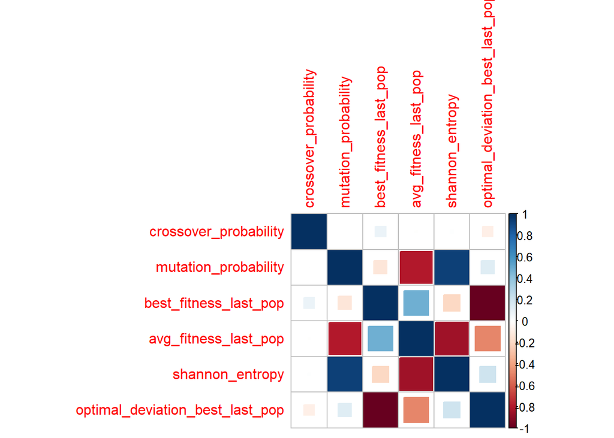

```r
corrplot(corr, method = "square")
```

Now, let’s plot the best fitness in the last population by crossover probability, mutation probability and both:

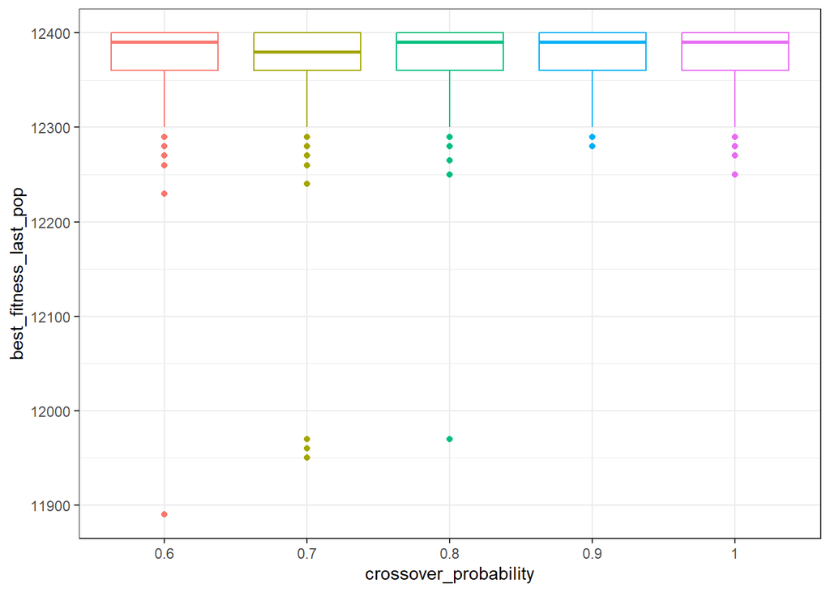

```r
df_study1_medium %>%
    mutate(crossover_probability = as.factor(crossover_probability)) %>%
    group_by(crossover_probability) %>%
    ggplot(mapping = aes(x = crossover_probability, y = best_fitness_last_pop, color=crossover_probability)) +
        geom_boxplot() +
        theme_bw() +
        theme(legend.position = "none")
```

We can see that the crossover probability does not seem to have a big effect on the obtained fitness. Let’s check the mutation probability:

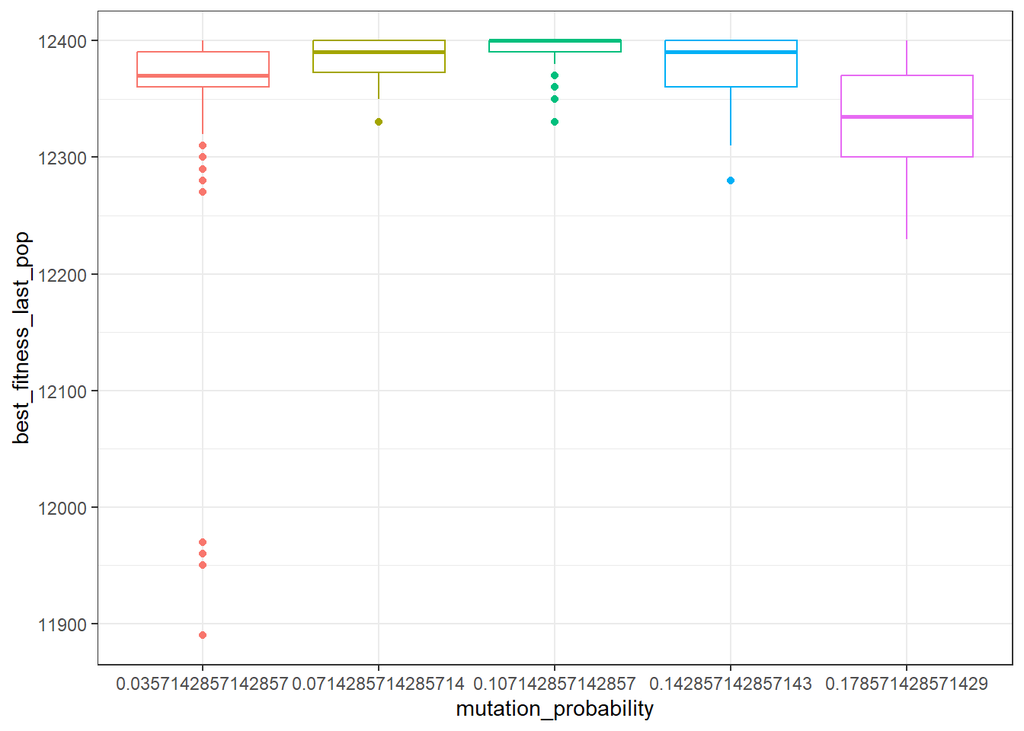

```r
df_study1_medium %>%
    mutate(mutation_probability = as.factor(mutation_probability)) %>%
    group_by(mutation_probability) %>%
    ggplot(mapping = aes(x = mutation_probability, y = best_fitness_last_pop, color=mutation_probability)) +
        geom_boxplot() +
        theme_bw() +
        theme(legend.position = "none")
```

Mutation seems to be more influential on the obtained fitness. In contrast to the small problem size, in this case we can see that a too small or to big mutation probability may yield worse results, and a balanced value may be better. Let’s plot each combination:

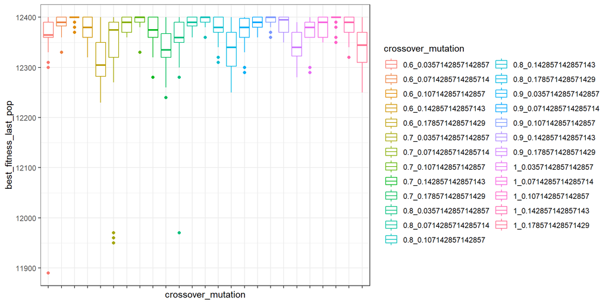

```r
df_study1_medium %>%
  group_by(crossover_probability, mutation_probability) %>%
  mutate(crossover_mutation = paste0(crossover_probability, "_", mutation_probability)) %>%
  ggplot(mapping = aes(x = crossover_mutation, y = best_fitness_last_pop, color=crossover_mutation)) +
    geom_boxplot() +
    theme_bw() +
    scale_x_discrete(labels = NULL)
```

Let’s see the average obtained fitness, its median and standard deviation and also how it is translated to the deviation from the optimal fitness:

```r
df_study1_medium_grouped <- df_study1_medium %>%
  mutate(crossover_mutation = paste0(crossover_probability, ",", mutation_probability)) %>%
  group_by(crossover_mutation) %>%
  summarise(
    avg_best_fitness_last_pop = mean(best_fitness_last_pop),
    median_best_fitness_last_pop = median(best_fitness_last_pop),
    std_best_fitness_last_pop = sd(best_fitness_last_pop),
    avg_optimal_deviation_best_last_pop = mean(optimal_deviation_best_last_pop),
    median_optimal_deviation_best_last_pop = median(optimal_deviation_best_last_pop),
    .groups = 'keep'
  )
df_study1_medium_grouped <- as.data.frame(df_study1_medium_grouped)
df_study1_medium_grouped
```

| crossover_mutation | avg_best_fitness_last_pop | median_best_fitness_last_pop | std_best_fitness_last_pop | avg_optimal_deviation_best_last_pop | median_optimal_deviation_best_last_pop |
| --- | --- | --- | --- | --- | --- |
| 0.6,0.0357142857142857 | 12352.67 | 12365 | 91.611373 | 0.0038172043 | 0.0028225806 |
| 0.6,0.0714285714285714 | 12386.00 | 12390 | 17.927055 | 0.0011290323 | 0.0008064516 |
| 0.6,0.107142857142857 | 12396.33 | 12400 | 7.648905 | 0.0002956989 | 0.0000000000 |
| 0.6,0.142857142857143 | 12376.67 | 12380 | 23.828892 | 0.0018817204 | 0.0016129032 |
| 0.6,0.178571428571429 | 12316.00 | 12305 | 47.314064 | 0.0067741935 | 0.0076612903 |
| 0.7,0.0357142857142857 | 12325.33 | 12375 | 128.807082 | 0.0060215054 | 0.0020161290 |
| 0.7,0.0714285714285714 | 12385.00 | 12390 | 16.347519 | 0.0012096774 | 0.0008064516 |
| 0.7,0.107142857142857 | 12391.33 | 12400 | 18.143743 | 0.0006989247 | 0.0000000000 |
| 0.7,0.142857142857143 | 12371.67 | 12375 | 29.253156 | 0.0022849462 | 0.0020161290 |
| 0.7,0.178571428571429 | 12335.33 | 12335 | 43.844029 | 0.0052150538 | 0.0052419355 |

[output cut: 15 more lines]

```r
df_study1_medium <- as.data.frame(df_study1_medium %>%
  mutate(crossover_mutation = paste0(crossover_probability, ",", mutation_probability)))
df_study1_medium
```

| crossover_probability | mutation_probability | best_fitness_last_pop | avg_fitness_last_pop | shannon_entropy | optimal_deviation_best_last_pop | crossover_mutation |
| --- | --- | --- | --- | --- | --- | --- |
| 0.6 | 0.03571429 | 12300 | 12298.80 | 0.002885469 | 0.0080645161 | 0.6,0.0357142857142857 |
| 0.6 | 0.03571429 | 12380 | 12379.40 | 0.002885469 | 0.0016129032 | 0.6,0.0357142857142857 |
| 0.6 | 0.03571429 | 12390 | 12266.09 | 0.005770938 | 0.0008064516 | 0.6,0.0357142857142857 |
| 0.6 | 0.03571429 | 12400 | 12400.00 | 0.000000000 | 0.0000000000 | 0.6,0.0357142857142857 |
| 0.6 | 0.03571429 | 12390 | 12390.00 | 0.000000000 | 0.0008064516 | 0.6,0.0357142857142857 |
| 0.6 | 0.03571429 | 12400 | 12373.00 | 0.005770938 | 0.0000000000 | 0.6,0.0357142857142857 |
| 0.6 | 0.03571429 | 11890 | 11890.00 | 0.000000000 | 0.0411290323 | 0.6,0.0357142857142857 |
| 0.6 | 0.03571429 | 12310 | 12283.70 | 0.008656407 | 0.0072580645 | 0.6,0.0357142857142857 |
| 0.6 | 0.03571429 | 12360 | 12360.00 | 0.000000000 | 0.0032258065 | 0.6,0.0357142857142857 |
| 0.6 | 0.03571429 | 12360 | 12360.00 | 0.000000000 | 0.0032258065 | 0.6,0.0357142857142857 |

[output cut: 740 more lines]

```r
# for (combination in levels(as.factor(df_study1_medium$crossover_mutation))) {
#   print(combination)
#   print(shapiro.test(
#     df_study1_medium[df_study1_medium$crossover_mutation == combination, 'optimal_deviation_best_last_pop']))
# }
```

Now, let’s run the Kruskal-Wallis test to check whether there’s a combination of parameters for which there’s enough statistical evidence to say that it does not belong to the same distribution:

```r
kruskal.test(optimal_deviation_best_last_pop ~ crossover_mutation, data = df_study1_medium)
```

```
##
##  Kruskal-Wallis rank sum test
##
## data:  optimal_deviation_best_last_pop by crossover_mutation
## Kruskal-Wallis chi-squared = 264.81, df = 24, p-value < 2.2e-16
```

We can see that the p-value is smaller than 0.02, so there’s at least one combination of parameters that comes from a population with a different distribution of values for the deviation from the optimal fitness. Let’s run the Wilcoxon test for each pair of combinations of parameters:

```r
result <- pairwise.wilcox.test(x = df_study1_medium$optimal_deviation_best_last_pop,
                               g = df_study1_medium$crossover_mutation,
                               p.adjust.method = "BH",
                               paired = FALSE)
print(result)
```

```
##
##  Pairwise comparisons using Wilcoxon rank sum test with continuity correction
##
## data:  df_study1_medium$optimal_deviation_best_last_pop and df_study1_medium$crossover_mutation
##
##                        0.6,0.0357142857142857 0.6,0.0714285714285714
## 0.6,0.0714285714285714 0.00963                -
## 0.6,0.107142857142857  4.3e-06                0.00781
## 0.6,0.142857142857143  0.23319                0.16367
## 0.6,0.178571428571429  0.00024                2.9e-07
## 0.7,0.0357142857142857 0.83461                0.00685
## 0.7,0.0714285714285714 0.01759                0.83540
## 0.7,0.107142857142857  0.00019                0.10350
## 0.7,0.142857142857143  0.48735                0.10312
## 0.7,0.178571428571429  0.01343                9.4e-06
## 0.8,0.0357142857142857 0.79303                0.00844
## 0.8,0.0714285714285714 0.00445                0.83707
## 0.8,0.107142857142857  4.6e-05                0.05893
## 0.8,0.142857142857143  0.13639                0.28205
## 0.8,0.178571428571429  0.00712                2.2e-06
## 0.9,0.0357142857142857 0.41722                0.10216
## 0.9,0.0714285714285714 0.00490                0.89678
## 0.9,0.107142857142857  0.00022                0.19781
## 0.9,0.142857142857143  0.00699                0.80775
## 0.9,0.178571428571429  0.02314                4.3e-06
## 1,0.0357142857142857   0.46567                0.06981
## 1,0.0714285714285714   0.01821                0.98785
## 1,0.107142857142857    1.3e-05                0.01047
## 1,0.142857142857143    0.03570                0.85204
## 1,0.178571428571429    0.01854                7.9e-06
##                        0.6,0.107142857142857 0.6,0.142857142857143
## 0.6,0.0714285714285714 -                     -
## 0.6,0.107142857142857  -                     -
## 0.6,0.142857142857143  0.00023               -
## 0.6,0.178571428571429  2.4e-08               7.0e-06
## 0.7,0.0357142857142857 2.6e-06               0.16976
## 0.7,0.0714285714285714 0.00450               0.26762
## 0.7,0.107142857142857  0.40592               0.00580
## 0.7,0.142857142857143  0.00022               0.69642
## 0.7,0.178571428571429  7.0e-08               0.00033
```

[output cut: 252 more lines]

```
## 0.8,0.107142857142857  -                   -
## 0.8,0.142857142857143  -                   -
## 0.8,0.178571428571429  -                   -
## 0.9,0.0357142857142857 -                   -
## 0.9,0.0714285714285714 -                   -
## 0.9,0.107142857142857  -                   -
## 0.9,0.142857142857143  -                   -
## 0.9,0.178571428571429  -                   -
## 1,0.0357142857142857   -                   -
## 1,0.0714285714285714   -                   -
## 1,0.107142857142857    -                   -
## 1,0.142857142857143    0.01551             -
## 1,0.178571428571429    9.5e-08             6.7e-05
##
## P value adjustment method: BH
```

```r
GetNumberDifferentPairs(result, 0.02)
```

```
## [1] "Number of different pairs: 160"
```

Let’s test crossover and mutation separately. If there is not enough evidence to say that crossover or mutation make a real difference in the results (separately), we would need to comeback to the pairwise results and check, along with the median values of the deviation from the optimal fitness, which combination would be better.

```r
df_study1_medium_grouped_crossover <- df_study1_medium %>%
  group_by(crossover_probability) %>%
  summarise(
    avg_best_fitness_last_pop = mean(best_fitness_last_pop),
    median_best_fitness_last_pop = median(best_fitness_last_pop),
    std_best_fitness_last_pop = sd(best_fitness_last_pop),
    avg_optimal_deviation_best_last_pop = mean(optimal_deviation_best_last_pop),
    median_optimal_deviation_best_last_pop = median(optimal_deviation_best_last_pop),
    .groups = 'keep'
  )
df_study1_medium_grouped_crossover <- as.data.frame(df_study1_medium_grouped_crossover)
df_study1_medium_grouped_crossover
```

| crossover_probability | avg_best_fitness_last_pop | median_best_fitness_last_pop | std_best_fitness_last_pop | avg_optimal_deviation_best_last_pop | median_optimal_deviation_best_last_pop |
| --- | --- | --- | --- | --- | --- |
| 0.6 | 12365.53 | 12390 | 55.50907 | 0.002779570 | 0.0008064516 |
| 0.7 | 12361.73 | 12380 | 67.81090 | 0.003086022 | 0.0016129032 |
| 0.8 | 12369.43 | 12390 | 47.14513 | 0.002465054 | 0.0008064516 |
| 0.9 | 12376.20 | 12390 | 29.48484 | 0.001919355 | 0.0008064516 |
| 1.0 | 12373.80 | 12390 | 34.32318 | 0.002112903 | 0.0008064516 |

```r
df_study1_medium_grouped_mutation <- df_study1_medium %>%
  group_by(mutation_probability) %>%
  summarise(
    avg_best_fitness_last_pop = mean(best_fitness_last_pop),
    median_best_fitness_last_pop = median(best_fitness_last_pop),
    std_best_fitness_last_pop = sd(best_fitness_last_pop),
    avg_optimal_deviation_best_last_pop = mean(optimal_deviation_best_last_pop),
    median_optimal_deviation_best_last_pop = median(optimal_deviation_best_last_pop),
    .groups = 'keep'
  )
df_study1_medium_grouped_mutation <- as.data.frame(df_study1_medium_grouped_mutation)
df_study1_medium_grouped_mutation
```

| mutation_probability | avg_best_fitness_last_pop | median_best_fitness_last_pop | std_best_fitness_last_pop | avg_optimal_deviation_best_last_pop | median_optimal_deviation_best_last_pop |
| --- | --- | --- | --- | --- | --- |
| 0.03571429 | 12353.93 | 12370 | 82.36355 | 0.0037150538 | 0.0024193548 |
| 0.07142857 | 12386.27 | 12390 | 16.28384 | 0.0011075269 | 0.0008064516 |
| 0.10714286 | 12393.67 | 12400 | 12.81865 | 0.0005107527 | 0.0000000000 |
| 0.14285714 | 12379.00 | 12390 | 24.15693 | 0.0016935484 | 0.0008064516 |
| 0.17857143 | 12333.83 | 12335 | 42.50707 | 0.0053360215 | 0.0052419355 |

```r
kruskal.test(optimal_deviation_best_last_pop ~ crossover_probability, data = df_study1_medium)
```

```
##
##  Kruskal-Wallis rank sum test
##
## data:  optimal_deviation_best_last_pop by crossover_probability
## Kruskal-Wallis chi-squared = 3.6908, df = 4, p-value = 0.4495
```

We can see that there’s not enough statistical evidence to assume that there’s at least a crossover probability which yields a better median of the deviation from the optimal fitness. Let’s test the mutation probability:

```r
kruskal.test(optimal_deviation_best_last_pop ~ mutation_probability, data = df_study1_medium)
```

```
##
##  Kruskal-Wallis rank sum test
##
## data:  optimal_deviation_best_last_pop by mutation_probability
## Kruskal-Wallis chi-squared = 254.31, df = 4, p-value < 2.2e-16
```

The p-value is smaller than the 0.02 level of significance so let’s apply the corrected Wilcoxon test between the results of every pair of mutation probabilities:

```r
pairwise.wilcox.test(x = df_study1_medium$optimal_deviation_best_last_pop,
                     g = df_study1_medium$mutation_probability,
                     p.adjust.method = "BH",
                     paired = FALSE)
```

```
##
##  Pairwise comparisons using Wilcoxon rank sum test with continuity correction
##
## data:  df_study1_medium$optimal_deviation_best_last_pop and df_study1_medium$mutation_probability
##
##                    0.0357142857142857 0.0714285714285714 0.107142857142857
## 0.0714285714285714 2.4e-08            -                  -
## 0.107142857142857  < 2e-16            1.9e-06            -
## 0.142857142857143  0.00053            0.03533            5.7e-10
## 0.178571428571429  1.5e-10            < 2e-16            < 2e-16
##                    0.142857142857143
## 0.0714285714285714 -
## 0.107142857142857  -
## 0.142857142857143  -
## 0.178571428571429  < 2e-16
##
## P value adjustment method: BH
```

As we can see, there’s enough evidence to say that each mutation probability yields different results compared to the rest, except between a probability of 0.0714285714285714 (average of 2 expected mutations in each individual) and 0.142857142857143 (average of 4 expected mutations in each individual). Thus, looking at the median deviation from the optimal fitness, it seems that using a mutation probability of 0.107142857142857 yields the best results, regardless the crossover (for the tested values of crossover, of course).

## Large problem size

The last problem instance that we will study is a relatively larger one, consisting of 50 items and 5 knapsacks. It corresponds to the 7th instance in the `mknap1.txt` file, which is the index 6:

```r
df_study1_large <- filter(df_study1, problem_index == 6)
str(df_study1_large)
```

```
## 'data.frame':    750 obs. of  13 variables:
##  $ problem_index        : int  6 6 6 6 6 6 6 6 6 6 ...
##  $ population_size      : int  200 200 200 200 200 200 200 200 200 200 ...
##  $ crossover_probability: num  0.6 0.6 0.6 0.6 0.6 0.6 0.6 0.6 0.6 0.6 ...
##  $ mutation_probability : num  0.02 0.02 0.02 0.02 0.02 0.02 0.02 0.02 0.02 0.02 ...
##  $ search_optimal       : int  0 0 0 0 0 0 0 0 0 0 ...
##  $ max_steps            : int  1000000 1000000 1000000 1000000 1000000 1000000 1000000 1000000 1000000 1000000 ...
##  $ optimal_fitness      : num  16537 16537 16537 16537 16537 ...
##  $ optimal_percentage   : num  100 100 100 100 100 100 100 100 100 100 ...
##  $ best_fitness_last_pop: num  16375 16428 16419 16423 16425 ...
##  $ avg_fitness_last_pop : num  16375 16346 16419 16408 16343 ...
##  $ shannon_entropy      : num  0 0.001817 0.000908 0.000908 0.000908 ...
##  $ num_evaluations      : int  1000200 1000200 1000200 1000200 1000200 1000200 1000200 1000200 1000200 1000200 ...
##  $ execution_time       : num  1.51 1.42 1.43 1.38 1.34 ...
```

Let’s repeat the same procedure as with the other instances:

```r
summary(df_study1_large[, colnames(df_study1_large) %in% columns_to_drop])
```

```
##  problem_index population_size search_optimal   max_steps     optimal_fitness
##  Min.   :6     Min.   :200     Min.   :0      Min.   :1e+06   Min.   :16537
##  1st Qu.:6     1st Qu.:200     1st Qu.:0      1st Qu.:1e+06   1st Qu.:16537
##  Median :6     Median :200     Median :0      Median :1e+06   Median :16537
##  Mean   :6     Mean   :200     Mean   :0      Mean   :1e+06   Mean   :16537
##  3rd Qu.:6     3rd Qu.:200     3rd Qu.:0      3rd Qu.:1e+06   3rd Qu.:16537
##  Max.   :6     Max.   :200     Max.   :0      Max.   :1e+06   Max.   :16537
##  optimal_percentage num_evaluations execution_time
##  Min.   :100        Min.   :1e+06   Min.   :1.292
##  1st Qu.:100        1st Qu.:1e+06   1st Qu.:1.325
##  Median :100        Median :1e+06   Median :1.346
##  Mean   :100        Mean   :1e+06   Mean   :1.370
##  3rd Qu.:100        3rd Qu.:1e+06   3rd Qu.:1.400
##  Max.   :100        Max.   :1e+06   Max.   :1.962
```

The population size that we used is twice the one we used for the previous two problems, as even if there are less constraints in the number of knapsacks, there are more items and it’s harder to get a relatively ‘good’ number of feasible random solutions for the initial population. Also, the fixed number of executions is 1000000, and we can see that the optimal fitness is 16537 (only relevant for the second study). Let’s compute the deviation from the optimal fitness:

```r
df_study1_large <- ComputeFitnessDeviation(df_study1_large)
```

```
##      Min.   1st Qu.    Median      Mean   3rd Qu.      Max.
## 0.0000000 0.0000000 0.0007861 0.0020976 0.0043539 0.0172341
```

Let’s drop the previous columns:

```r
df_study1_large <- DropColumns(df_study1_large, columns_to_drop)
```

```
## [1] "crossover_probability"           "mutation_probability"
## [3] "best_fitness_last_pop"           "avg_fitness_last_pop"
## [5] "shannon_entropy"                 "optimal_deviation_best_last_pop"
```

Let’s check the correlation between the variables:

```r
corr <- cor(df_study1_large)
corr
```

```
##                                 crossover_probability mutation_probability
## crossover_probability                    1.000000e+00        -2.162757e-19
## mutation_probability                    -2.162757e-19         1.000000e+00
## best_fitness_last_pop                    2.897206e-02         6.296939e-01
## avg_fitness_last_pop                     2.805073e-02         3.557192e-01
## shannon_entropy                          2.519477e-02         2.924618e-01
## optimal_deviation_best_last_pop         -2.897206e-02        -6.296939e-01
##                                 best_fitness_last_pop avg_fitness_last_pop
## crossover_probability                      0.02897206           0.02805073
## mutation_probability                       0.62969391           0.35571918
## best_fitness_last_pop                      1.00000000           0.73490249
## avg_fitness_last_pop                       0.73490249           1.00000000
## shannon_entropy                            0.13369104           0.03523385
## optimal_deviation_best_last_pop           -1.00000000          -0.73490249
##                                 shannon_entropy optimal_deviation_best_last_pop
## crossover_probability                0.02519477                     -0.02897206
## mutation_probability                 0.29246179                     -0.62969391
## best_fitness_last_pop                0.13369104                     -1.00000000
## avg_fitness_last_pop                 0.03523385                     -0.73490249
## shannon_entropy                      1.00000000                     -0.13369104
## optimal_deviation_best_last_pop     -0.13369104                      1.00000000
```

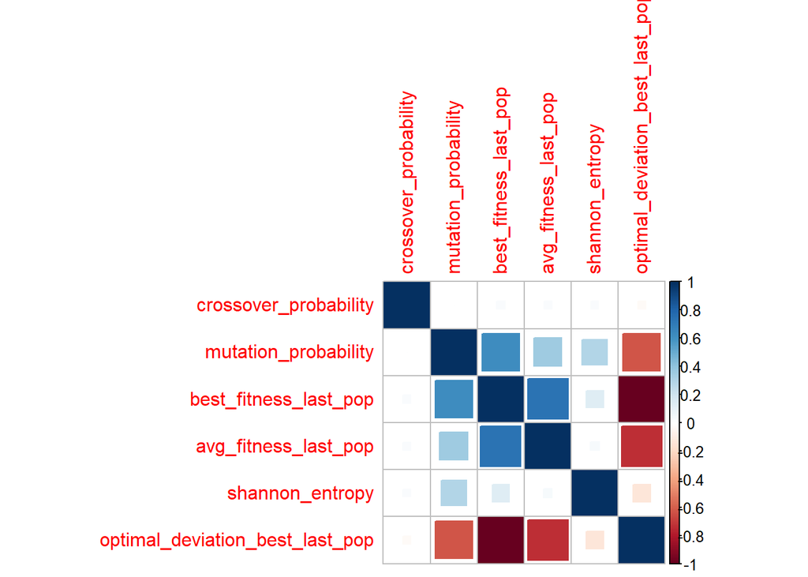

```r
corrplot(corr, method = "square")
```

Now, let’s plot the best fitness in the last population by crossover probability, mutation probability and both:

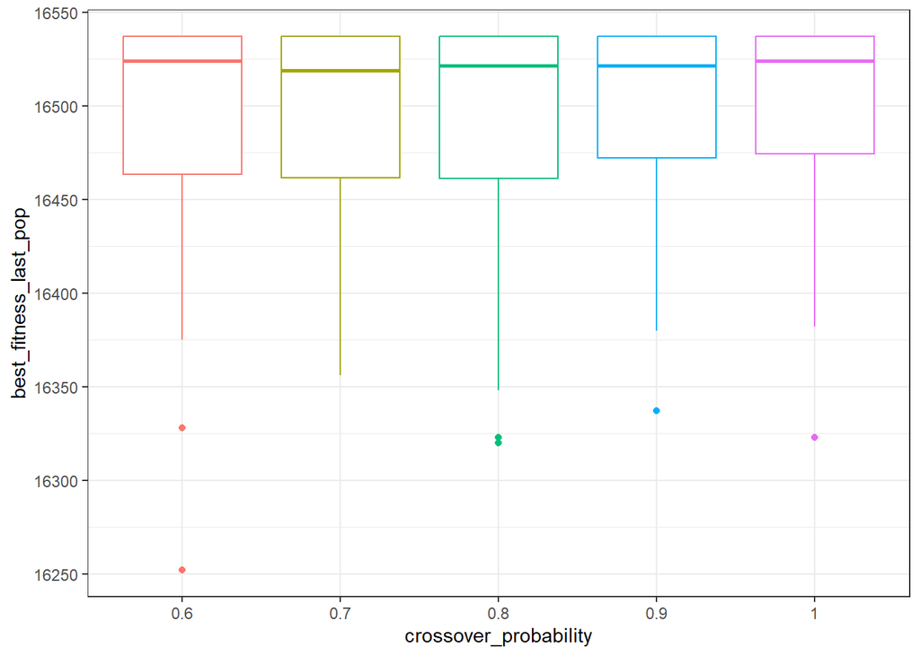

```r
df_study1_large %>%
    mutate(crossover_probability = as.factor(crossover_probability)) %>%
    group_by(crossover_probability) %>%
    ggplot(mapping = aes(x = crossover_probability, y = best_fitness_last_pop, color=crossover_probability)) +
        geom_boxplot() +
        theme_bw() +
        theme(legend.position = "none")
```

As always so far the crossover probability does not seem to have at first glance any relevant effect on the obtained fitness. Let’s check the mutation probability:

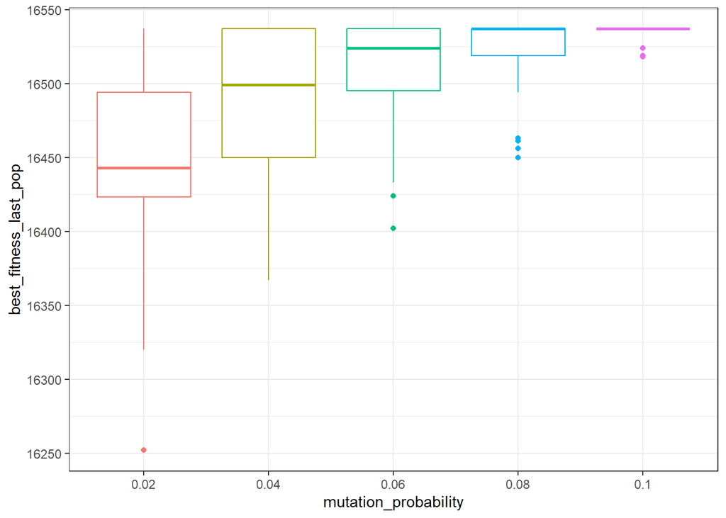

```r
df_study1_large %>%
    mutate(mutation_probability = as.factor(mutation_probability)) %>%
    group_by(mutation_probability) %>%
    ggplot(mapping = aes(x = mutation_probability, y = best_fitness_last_pop, color=mutation_probability)) +
        geom_boxplot() +
        theme_bw() +
        theme(legend.position = "none")
```

Mutation seems to be more influential on the obtained fitness. In this case, it seems that a larger number of average mutated genes per individual is better (in the range that we have tested, from 1 to 5). This is different to the small instance (1 > 2 > 3 > 4 > 5) and the medium one (3 > 2-4 > 1 > 5). Thus, we can conclude that for smaller problems, if we compute the mutation probability given the number of expected mutated genes per individual on average (by chance), we should use smaller values than for larger problems.

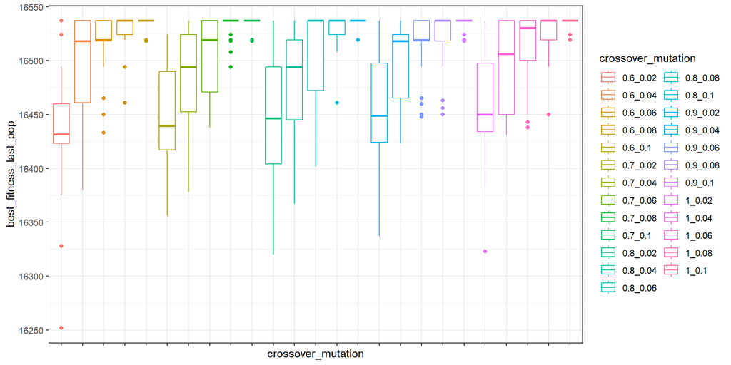

```r
df_study1_large %>%
  group_by(crossover_probability, mutation_probability) %>%
  mutate(crossover_mutation = paste0(crossover_probability, "_", mutation_probability)) %>%
  ggplot(mapping = aes(x = crossover_mutation, y = best_fitness_last_pop, color=crossover_mutation)) +
    geom_boxplot() +
    theme_bw() +
    scale_x_discrete(labels = NULL)
```

Let’s see the average obtained fitness, its median and standard deviation and also how it is translated to the deviation from the optimal:

```r
df_study1_large_grouped <- df_study1_large %>%
  mutate(crossover_mutation = paste0(crossover_probability, ",", mutation_probability)) %>%
  group_by(crossover_mutation) %>%
  summarise(
    avg_best_fitness_last_pop = mean(best_fitness_last_pop),
    median_best_fitness_last_pop = median(best_fitness_last_pop),
    std_best_fitness_last_pop = sd(best_fitness_last_pop),
    avg_optimal_deviation_best_last_pop = mean(optimal_deviation_best_last_pop),
    median_optimal_deviation_best_last_pop = median(optimal_deviation_best_last_pop),
    .groups = 'keep'
  )
df_study1_large_grouped <- as.data.frame(df_study1_large_grouped)
df_study1_large_grouped
```

| crossover_mutation | avg_best_fitness_last_pop | median_best_fitness_last_pop | std_best_fitness_last_pop | avg_optimal_deviation_best_last_pop | median_optimal_deviation_best_last_pop |
| --- | --- | --- | --- | --- | --- |
| 0.6,0.02 | 16438.07 | 16431.5 | 58.226036 | 5.982544e-03 | 0.006379634 |
| 0.6,0.04 | 16493.07 | 16518.0 | 43.712172 | 2.656669e-03 | 0.001148939 |
| 0.6,0.06 | 16518.20 | 16519.0 | 26.616562 | 1.136845e-03 | 0.001088468 |
| 0.6,0.08 | 16529.33 | 16537.0 | 16.257271 | 4.636069e-04 | 0.000000000 |
| 0.6,0.1 | 16533.93 | 16537.0 | 6.977468 | 1.854427e-04 | 0.000000000 |
| 0.7,0.02 | 16446.47 | 16439.5 | 51.110923 | 5.474592e-03 | 0.005895870 |
| 0.7,0.04 | 16487.30 | 16494.0 | 45.366059 | 3.005382e-03 | 0.002600230 |
| 0.7,0.06 | 16506.10 | 16519.0 | 35.073666 | 1.868537e-03 | 0.001088468 |
| 0.7,0.08 | 16531.73 | 16537.0 | 10.763711 | 3.184778e-04 | 0.000000000 |
| 0.7,0.1 | 16532.73 | 16537.0 | 7.869335 | 2.580073e-04 | 0.000000000 |

[output cut: 15 more lines]

Let’s create a new attribute combining crossover and mutation probabilities for easing the testing of each one:

```r
df_study1_large <- as.data.frame(df_study1_large %>%
  mutate(crossover_mutation = paste0(crossover_probability, ",", mutation_probability)))
df_study1_large
```

| crossover_probability | mutation_probability | best_fitness_last_pop | avg_fitness_last_pop | shannon_entropy | optimal_deviation_best_last_pop | crossover_mutation |
| --- | --- | --- | --- | --- | --- | --- |
| 0.6 | 0.02 | 16375 | 16375.00 | 0.0000000000 | 0.009796215 | 0.6,0.02 |
| 0.6 | 0.02 | 16428 | 16345.85 | 0.0018165877 | 0.006591280 | 0.6,0.02 |
| 0.6 | 0.02 | 16419 | 16418.54 | 0.0009082938 | 0.007135514 | 0.6,0.02 |
| 0.6 | 0.02 | 16423 | 16407.70 | 0.0009082938 | 0.006893632 | 0.6,0.02 |
| 0.6 | 0.02 | 16425 | 16342.87 | 0.0009082938 | 0.006772692 | 0.6,0.02 |
| 0.6 | 0.02 | 16433 | 16433.00 | 0.0000000000 | 0.006288928 | 0.6,0.02 |
| 0.6 | 0.02 | 16401 | 16401.00 | 0.0000000000 | 0.008223983 | 0.6,0.02 |
| 0.6 | 0.02 | 16455 | 16430.60 | 0.0018165877 | 0.004958578 | 0.6,0.02 |
| 0.6 | 0.02 | 16328 | 16328.00 | 0.0000000000 | 0.012638326 | 0.6,0.02 |
| 0.6 | 0.02 | 16450 | 16449.55 | 0.0009082938 | 0.005260930 | 0.6,0.02 |

[output cut: 740 more lines]

```r
# for (combination in levels(as.factor(df_study1_large$crossover_mutation))) {
#   print(combination)
#   print(shapiro.test(
#     df_study1_large[df_study1_large$crossover_mutation == combination, 'optimal_deviation_best_last_pop']))
# }
```

Let’s run the Kruskal-Wallis test:

```r
kruskal.test(optimal_deviation_best_last_pop ~ crossover_mutation, data = df_study1_large)
```

```
##
##  Kruskal-Wallis rank sum test
##
## data:  optimal_deviation_best_last_pop by crossover_mutation
## Kruskal-Wallis chi-squared = 350.83, df = 24, p-value < 2.2e-16
```

We can see that the p-value is smaller than 0.02, so there’s at least one combination of parameters that comes from a population with a different distribution of values for the deviation from the optimal fitness. Let’s run the Wilcoxon test for each pair of combinations of parameters:

```r
result <- pairwise.wilcox.test(x = df_study1_large$optimal_deviation_best_last_pop,
                               g = df_study1_large$crossover_mutation,
                               p.adjust.method = "BH",
                               paired = FALSE)
print(result)
```

```
##
##  Pairwise comparisons using Wilcoxon rank sum test with continuity correction
##
## data:  df_study1_large$optimal_deviation_best_last_pop and df_study1_large$crossover_mutation
##
##          0.6,0.02 0.6,0.04 0.6,0.06 0.6,0.08 0.6,0.1 0.7,0.02 0.7,0.04 0.7,0.06
## 0.6,0.04 0.00020  -        -        -        -       -        -        -
## 0.6,0.06 7.0e-07  0.05867  -        -        -       -        -        -
## 0.6,0.08 8.4e-09  0.00037  0.02361  -        -       -        -        -
## 0.6,0.1  2.1e-09  2.7e-05  0.00247  0.34628  -       -        -        -
## 0.7,0.02 0.76371  0.00033  4.8e-07  2.9e-09  1.1e-09 -        -        -
## 0.7,0.04 0.00105  0.58696  0.01109  5.2e-05  2.9e-06 0.00319  -        -
## 0.7,0.06 1.0e-05  0.41108  0.36796  0.00250  0.00018 1.1e-05  0.14141  -
## 0.7,0.08 3.9e-09  0.00013  0.01239  0.70392  0.57575 2.2e-09  1.4e-05  0.00099
## 0.7,0.1  3.9e-09  0.00010  0.00903  0.71568  0.61041 1.5e-09  9.9e-06  0.00082
## 0.8,0.02 0.82923  0.00055  4.2e-07  5.7e-09  1.5e-09 0.86481  0.00419  1.8e-05
## 0.8,0.04 0.00631  0.31714  0.00377  1.2e-05  1.0e-06 0.01176  0.66471  0.04676
## 0.8,0.06 1.3e-05  0.15922  0.81985  0.06778  0.00669 1.8e-05  0.05278  0.50741
## 0.8,0.08 1.1e-08  0.00080  0.05056  0.89273  0.28266 5.8e-09  8.8e-05  0.00499
## 0.8,0.1  1.5e-09  9.8e-06  0.00055  0.17742  0.70365 9.5e-10  1.2e-06  5.0e-05
## 0.9,0.02 0.40027  0.00319  6.8e-06  2.5e-08  2.7e-09 0.53254  0.01827  0.00015
## 0.9,0.04 0.00011  0.95870  0.05835  0.00015  9.3e-06 0.00029  0.58917  0.37796
## 0.9,0.06 3.3e-06  0.19380  0.67285  0.00664  0.00059 1.6e-06  0.04812  0.65952
## 0.9,0.08 5.4e-08  0.00520  0.26624  0.51832  0.10920 6.4e-08  0.00081  0.03636
## 0.9,0.1  2.6e-09  4.9e-05  0.00388  0.49183  0.81967 1.3e-09  4.9e-06  0.00032
## 1,0.02   0.26389  0.00282  2.9e-06  1.2e-08  2.1e-09 0.51081  0.01629  8.8e-05
## 1,0.04   8.6e-05  0.86179  0.12045  0.00159  0.00012 0.00013  0.51832  0.52205
## 1,0.06   1.0e-06  0.06656  0.83389  0.07629  0.00814 1.0e-06  0.01976  0.28546
## 1,0.08   3.7e-08  0.00218  0.13089  0.48903  0.11658 1.1e-08  0.00025  0.01927
## 1,0.1    9.5e-10  1.6e-06  6.4e-05  0.02962  0.25893 9.5e-10  2.3e-07  5.3e-06
##          0.7,0.08 0.7,0.1 0.8,0.02 0.8,0.04 0.8,0.06 0.8,0.08 0.8,0.1 0.9,0.02
## 0.6,0.04 -        -       -        -        -        -        -       -
## 0.6,0.06 -        -       -        -        -        -        -       -
## 0.6,0.08 -        -       -        -        -        -        -       -
## 0.6,0.1  -        -       -        -        -        -        -       -
## 0.7,0.02 -        -       -        -        -        -        -       -
## 0.7,0.04 -        -       -        -        -        -        -       -
## 0.7,0.06 -        -       -        -        -        -        -       -
## 0.7,0.08 -        -       -        -        -        -        -       -
## 0.7,0.1  0.96335  -       -        -        -        -        -       -
```

[output cut: 27 more lines]

```
## 0.8,0.06 -        -        -        -       -       -       -       -
## 0.8,0.08 -        -        -        -       -       -       -       -
## 0.8,0.1  -        -        -        -       -       -       -       -
## 0.9,0.02 -        -        -        -       -       -       -       -
## 0.9,0.04 -        -        -        -       -       -       -       -
## 0.9,0.06 0.16185  -        -        -       -       -       -       -
## 0.9,0.08 0.00386  0.09667  -        -       -       -       -       -
## 0.9,0.1  1.5e-05  0.00102  0.16572  -       -       -       -       -
## 1,0.02   0.00279  1.3e-05  2.8e-07  2.5e-09 -       -       -       -
## 1,0.04   0.75641  0.26694  0.01109  0.00021 0.00140 -       -       -
## 1,0.06   0.04945  0.51832  0.30709  0.01411 6.5e-06 0.14081 -       -
## 1,0.08   0.00125  0.05287  0.86256  0.17094 5.1e-08 0.00595 0.26289 -
## 1,0.1    2.9e-07  1.3e-05  0.01120  0.15829 9.5e-10 9.7e-06 0.00037 0.00630
##
## P value adjustment method: BH
```

```r
GetNumberDifferentPairs(result, 0.02)
```

```
## [1] "Number of different pairs: 186"
```

As before, there are many pairs of combinations that yield different results when compared to each other. It is also nice to confirm that if we check the p-values of the tests between combinations with different crossover probability and the same mutation probability, they seem to be high and thus they would absolutely not be rejected in the test. Still, let’s confirm it by applying tests to crossover and mutation probabilities separately:

```r
df_study1_large_grouped_crossover <- df_study1_large %>%
  group_by(crossover_probability) %>%
  summarise(
    avg_best_fitness_last_pop = mean(best_fitness_last_pop),
    median_best_fitness_last_pop = median(best_fitness_last_pop),
    std_best_fitness_last_pop = sd(best_fitness_last_pop),
    avg_optimal_deviation_best_last_pop = mean(optimal_deviation_best_last_pop),
    median_optimal_deviation_best_last_pop = median(optimal_deviation_best_last_pop),
    .groups = 'keep'
  )
df_study1_large_grouped_crossover <- as.data.frame(df_study1_large_grouped_crossover)
df_study1_large_grouped_crossover
```

| crossover_probability | avg_best_fitness_last_pop | median_best_fitness_last_pop | std_best_fitness_last_pop | avg_optimal_deviation_best_last_pop | median_optimal_deviation_best_last_pop |
| --- | --- | --- | --- | --- | --- |
| 0.6 | 16502.52 | 16524.0 | 49.77853 | 0.002085021 | 0.0007861160 |
| 0.7 | 16500.87 | 16519.0 | 47.09289 | 0.002184999 | 0.0010884683 |
| 0.8 | 16498.33 | 16521.5 | 52.57410 | 0.002338191 | 0.0009372921 |
| 0.9 | 16504.08 | 16521.5 | 43.41752 | 0.001990688 | 0.0009372921 |
| 1.0 | 16505.76 | 16524.0 | 43.48828 | 0.001889097 | 0.0007861160 |

```r
df_study1_large_grouped_mutation <- df_study1_large %>%
  group_by(mutation_probability) %>%
  summarise(
    avg_best_fitness_last_pop = mean(best_fitness_last_pop),
    median_best_fitness_last_pop = median(best_fitness_last_pop),
    std_best_fitness_last_pop = sd(best_fitness_last_pop),
    avg_optimal_deviation_best_last_pop = mean(optimal_deviation_best_last_pop),
    median_optimal_deviation_best_last_pop = median(optimal_deviation_best_last_pop),
    .groups = 'keep'
  )
df_study1_large_grouped_mutation <- as.data.frame(df_study1_large_grouped_mutation)
df_study1_large_grouped_mutation
```

| mutation_probability | avg_best_fitness_last_pop | median_best_fitness_last_pop | std_best_fitness_last_pop | avg_optimal_deviation_best_last_pop | median_optimal_deviation_best_last_pop |
| --- | --- | --- | --- | --- | --- |
| 0.02 | 16447.07 | 16443 | 53.684399 | 0.0054379069 | 0.005684223 |
| 0.04 | 16491.17 | 16499 | 43.521408 | 0.0027715628 | 0.002297877 |
| 0.06 | 16511.47 | 16524 | 33.840069 | 0.0015436093 | 0.000786116 |
| 0.08 | 16527.70 | 16537 | 18.816225 | 0.0005623753 | 0.000000000 |
| 0.10 | 16534.15 | 16537 | 6.587956 | 0.0001725424 | 0.000000000 |

```r
kruskal.test(optimal_deviation_best_last_pop ~ crossover_probability, data = df_study1_large)
```

```
##
##  Kruskal-Wallis rank sum test
##
## data:  optimal_deviation_best_last_pop by crossover_probability
## Kruskal-Wallis chi-squared = 1.6399, df = 4, p-value = 0.8016
```

We can confirm that there’s not enough statistical evidence to assume that there’s at least a crossover probability which yields a better median of the deviation from the optimal fitness. Let’s test the mutation probability:

```r
kruskal.test(optimal_deviation_best_last_pop ~ mutation_probability, data = df_study1_large)
```

```
##
##  Kruskal-Wallis rank sum test
##
## data:  optimal_deviation_best_last_pop by mutation_probability
## Kruskal-Wallis chi-squared = 344.4, df = 4, p-value < 2.2e-16
```

The p-value is smaller than the 0.02 level of significance so let’s apply the corrected Wilcoxon test between the results of every pair of mutation probabilities:

```r
pairwise.wilcox.test(x = df_study1_large$optimal_deviation_best_last_pop,
                     g = df_study1_large$mutation_probability,
                     p.adjust.method = "BH",
                     paired = FALSE)
```

```
##
##  Pairwise comparisons using Wilcoxon rank sum test with continuity correction
##
## data:  df_study1_large$optimal_deviation_best_last_pop and df_study1_large$mutation_probability
##
##      0.02    0.04    0.06    0.08
## 0.04 3.1e-13 -       -       -
## 0.06 < 2e-16 2.3e-05 -       -
## 0.08 < 2e-16 < 2e-16 9.6e-07 -
## 0.1  < 2e-16 < 2e-16 1.5e-14 0.0014
##
## P value adjustment method: BH
```

For this instance, it seems that every mutation probability value yields different results to the rest in the deviation from the optimal fitness, as all the p-values are smaller than the 0.02 level of significance. Looking at the median and average results, it seems that a mutation probability of 0.1 yields the best results (regardless of the crossover probability in the grid of values that we checked).

# Study 2: search for optimal fitness

In this second study, the algorithm is executed until we reach the specified target fitness (which can be the optimal or some percentage of it as we will see in later sections), instead of a fixed number of evaluations. Thus, what we will measure to know which combination of parameters yields better results is the number of evaluations needed to reach that fitness.

```r
df_study2 <- filter(df, search_optimal == 1)
str(df_study2)
```

```
## 'data.frame':    4271 obs. of  13 variables:
##  $ problem_index        : int  2 2 2 2 2 2 2 2 2 2 ...
##  $ population_size      : int  100 100 100 100 100 100 100 100 100 100 ...
##  $ crossover_probability: num  0.6 0.6 0.6 0.6 0.6 0.6 0.6 0.6 0.6 0.6 ...
##  $ mutation_probability : num  0.0667 0.0667 0.0667 0.0667 0.0667 ...
##  $ search_optimal       : int  1 1 1 1 1 1 1 1 1 1 ...
##  $ max_steps            : int  1000 1000 1000 1000 1000 1000 1000 1000 1000 1000 ...
##  $ optimal_fitness      : num  4015 4015 4015 4015 4015 ...
##  $ optimal_percentage   : num  100 100 100 100 100 100 100 100 100 100 ...
##  $ best_fitness_last_pop: num  4015 4015 4015 4015 4015 ...
##  $ avg_fitness_last_pop : num  3657 3813 3995 4005 4005 ...
##  $ shannon_entropy      : num  0.6631 0.4562 0.0108 0.0162 0.0407 ...
##  $ num_evaluations      : int  451 896 1513 9844 2513 754 2607 1149 14771 5039 ...
##  $ execution_time       : num  0.001 0.001 0.001 0.007 0.002 0 0.002 0.001 0.012 0.003 ...
```

## Small problem size

```r
df_study2_small <- filter(df_study2, problem_index == 2)
str(df_study2_small)
```

```
## 'data.frame':    750 obs. of  13 variables:
##  $ problem_index        : int  2 2 2 2 2 2 2 2 2 2 ...
##  $ population_size      : int  100 100 100 100 100 100 100 100 100 100 ...
##  $ crossover_probability: num  0.6 0.6 0.6 0.6 0.6 0.6 0.6 0.6 0.6 0.6 ...
##  $ mutation_probability : num  0.0667 0.0667 0.0667 0.0667 0.0667 ...
##  $ search_optimal       : int  1 1 1 1 1 1 1 1 1 1 ...
##  $ max_steps            : int  1000 1000 1000 1000 1000 1000 1000 1000 1000 1000 ...
##  $ optimal_fitness      : num  4015 4015 4015 4015 4015 ...
##  $ optimal_percentage   : num  100 100 100 100 100 100 100 100 100 100 ...
##  $ best_fitness_last_pop: num  4015 4015 4015 4015 4015 ...
##  $ avg_fitness_last_pop : num  3657 3813 3995 4005 4005 ...
##  $ shannon_entropy      : num  0.6631 0.4562 0.0108 0.0162 0.0407 ...
##  $ num_evaluations      : int  451 896 1513 9844 2513 754 2607 1149 14771 5039 ...
##  $ execution_time       : num  0.001 0.001 0.001 0.007 0.002 0 0.002 0.001 0.012 0.003 ...
```

Let’s see some of the columns that we will drop as now are not relevant or they correspond to fixed parameters:

```r
columns_to_drop <- c('problem_index', 'population_size', 'search_optimal', 'max_steps', 'optimal_fitness', 'optimal_percentage', 'best_fitness_last_pop')
summary(df_study2_small[, colnames(df_study2_small) %in% columns_to_drop])
```

```
##  problem_index population_size search_optimal   max_steps    optimal_fitness
##  Min.   :2     Min.   :100     Min.   :1      Min.   :1000   Min.   :4015
##  1st Qu.:2     1st Qu.:100     1st Qu.:1      1st Qu.:1000   1st Qu.:4015
##  Median :2     Median :100     Median :1      Median :1000   Median :4015
##  Mean   :2     Mean   :100     Mean   :1      Mean   :1000   Mean   :4015
##  3rd Qu.:2     3rd Qu.:100     3rd Qu.:1      3rd Qu.:1000   3rd Qu.:4015
##  Max.   :2     Max.   :100     Max.   :1      Max.   :1000   Max.   :4015
##  optimal_percentage best_fitness_last_pop
##  Min.   :100        Min.   :4015
##  1st Qu.:100        1st Qu.:4015
##  Median :100        Median :4015
##  Mean   :100        Mean   :4015
##  3rd Qu.:100        3rd Qu.:4015
##  Max.   :100        Max.   :4015
```

As we can see, the population size that we used was 100 individuals, the same used in the first study, but in this case the value of `max_steps` is irrelevant as it is not used; the executions could only end reaching the 100% percent (look at `optimal_percentage`) of the optimal fitness. We can also see that this was the case, as the mean of `best_fitness_last_pop` is equal to the optimal fitness of the problem, 4015.

In this case we don’t have to create any new variable as we did in the first study with the deviation from the optimal fitness, so let’s drop these columns:

```r
df_study2_small <- DropColumns(df_study2_small, columns_to_drop)
```

```
## [1] "crossover_probability" "mutation_probability"  "avg_fitness_last_pop"
## [4] "shannon_entropy"       "num_evaluations"       "execution_time"
```

Let’s check the correlation between the variables:

```r
corr <- cor(df_study2_small)
corr
```

```
##                       crossover_probability mutation_probability
## crossover_probability          1.000000e+00        -2.280213e-19
## mutation_probability          -2.280213e-19         1.000000e+00
## avg_fitness_last_pop          -1.630289e-02        -1.753718e-01
## shannon_entropy                4.933391e-02         5.207850e-01
## num_evaluations               -2.864377e-02         2.703499e-01
## execution_time                -4.081109e-02         2.161477e-01
##                       avg_fitness_last_pop shannon_entropy num_evaluations
## crossover_probability          -0.01630289      0.04933391     -0.02864377
## mutation_probability           -0.17537181      0.52078501      0.27034989
## avg_fitness_last_pop            1.00000000     -0.63752067      0.33049096
## shannon_entropy                -0.63752067      1.00000000     -0.37838279
## num_evaluations                 0.33049096     -0.37838279      1.00000000
## execution_time                  0.23035035     -0.24251563      0.69383083
##                       execution_time
## crossover_probability    -0.04081109
## mutation_probability      0.21614765
## avg_fitness_last_pop      0.23035035
## shannon_entropy          -0.24251563
## num_evaluations           0.69383083
## execution_time            1.00000000
```

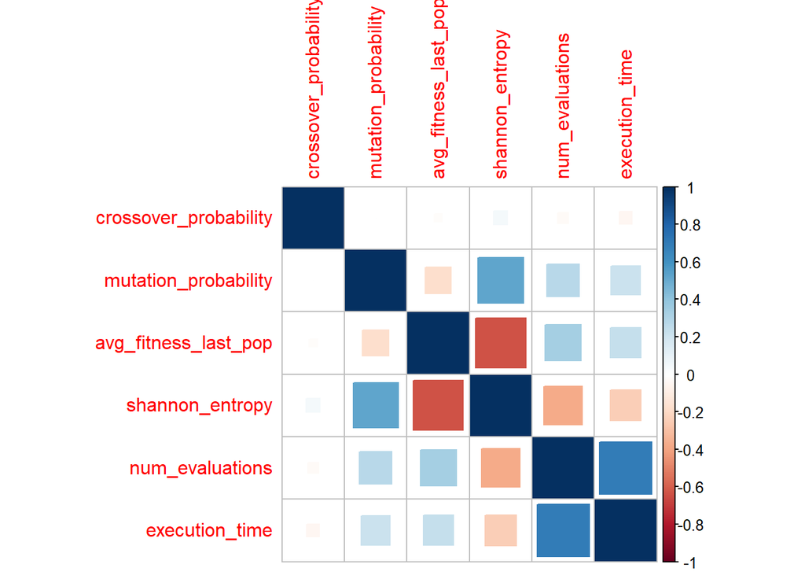

```r
corrplot(corr, method = "square")
```

Besides the obvious ones (like number of evaluations and execution time, inverse Shannon entropy and average fitness in the last population), there’s certain correlation (0.33) between the average fitness of the last population and the number of evaluations.

As the number of evaluation and the execution time are highly correlated, we can take the more granular one, i.e., the number of evaluations, in order to test the different combinations of crossover and mutation probabilities:

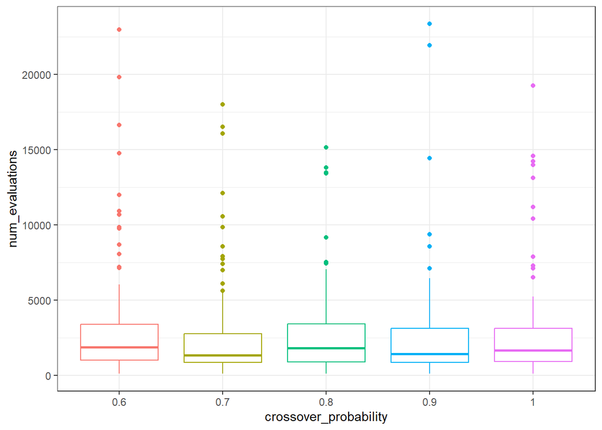

```r
df_study2_small %>%
    mutate(crossover_probability = as.factor(crossover_probability)) %>%
    group_by(crossover_probability) %>%
    ggplot(mapping = aes(x = crossover_probability, y = num_evaluations, color=crossover_probability)) +
        geom_boxplot() +
        theme_bw() +
        theme(legend.position = "none")
```

At first glance, crossover does not seem to have a clear effect on the number of evaluations needed to reach the optimal fitness. Let’s check the mutation probability:

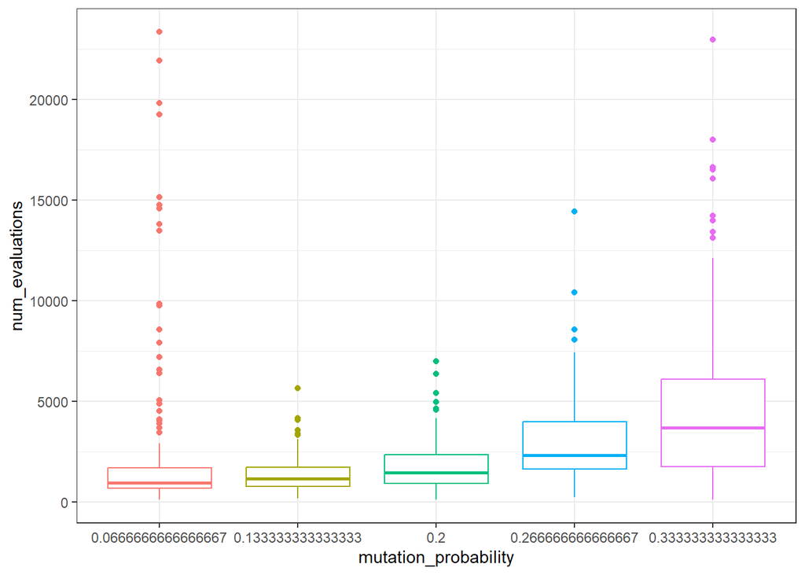

```r
df_study2_small %>%
    mutate(mutation_probability = as.factor(mutation_probability)) %>%
    group_by(mutation_probability) %>%
    ggplot(mapping = aes(x = mutation_probability, y = num_evaluations, color=mutation_probability)) +
        geom_boxplot() +
        theme_bw() +
        theme(legend.position = "none")
```

Similarly to the first study, it seems that the optimal fitness is reached on average on a smaller number of evaluations when the mutation probability is smaller, even though there seems to be a little bit of instability with the smallest mutation probability (in contrast to the second smallest one, for example).

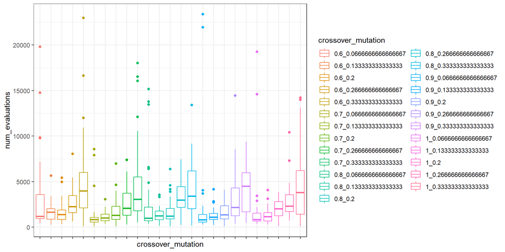

```r
df_study2_small %>%
  group_by(crossover_probability, mutation_probability) %>%
  mutate(crossover_mutation = paste0(crossover_probability, "_", mutation_probability)) %>%
  ggplot(mapping = aes(x = crossover_mutation, y = num_evaluations, color=crossover_mutation)) +
    geom_boxplot() +
    theme_bw() +
    scale_x_discrete(labels = NULL)
```

Let’s obtain the mean, median and standard deviation in the number of evaluations for each combination of crossover and mutation probabilities:

```r
df_study2_small_grouped <- df_study2_small %>%
  mutate(crossover_mutation = paste0(crossover_probability, ",", mutation_probability)) %>%
  group_by(crossover_mutation) %>%
  summarise(
    avg_num_evaluations = mean(num_evaluations),
    median_num_evaluations = median(num_evaluations),
    std_num_evaluations = sd(num_evaluations),
    .groups = 'keep'
  )
df_study2_small_grouped <- as.data.frame(df_study2_small_grouped)
df_study2_small_grouped
```

| crossover_mutation | avg_num_evaluations | median_num_evaluations | std_num_evaluations |
| --- | --- | --- | --- |
| 0.6,0.0666666666666667 | 3335.667 | 1201.5 | 4604.3408 |
| 0.6,0.133333333333333 | 1724.333 | 1653.0 | 1094.7257 |
| 0.6,0.2 | 1666.267 | 1387.5 | 1224.5971 |
| 0.6,0.266666666666667 | 2876.133 | 2247.5 | 1902.7583 |
| 0.6,0.333333333333333 | 5302.400 | 3976.0 | 5097.5809 |
| 0.7,0.0666666666666667 | 1433.700 | 852.5 | 2002.0241 |
| 0.7,0.133333333333333 | 1116.233 | 1029.0 | 587.0623 |
| 0.7,0.2 | 1834.500 | 1317.0 | 1483.6107 |
| 0.7,0.266666666666667 | 2662.767 | 2081.5 | 1743.3328 |
| 0.7,0.333333333333333 | 5044.333 | 3050.0 | 4975.6167 |

[output cut: 15 more lines]

There are two combinations that stands out at first glance if we consider the balance of both the mean and the median: (crossover = 0.7, mutation = 0.0666666666666667) and (crossover = 0.7, mutation = 0.133333333333333). Between these two, the second one may be better as the standard deviation is considerably smaller, which may tell us that on different random seeds we may consistently get more similar results.

Let’s create a new variable with the value of both the crossover and the mutation probabilities for easier handling in the statistical tests:

```r
df_study2_small <- as.data.frame(df_study2_small %>%
  mutate(crossover_mutation = paste0(crossover_probability, ",", mutation_probability)))
df_study2_small
```

| crossover_probability | mutation_probability | avg_fitness_last_pop | shannon_entropy | num_evaluations | execution_time | crossover_mutation |
| --- | --- | --- | --- | --- | --- | --- |
| 0.6 | 0.06666667 | 3656.85 | 0.66309971 | 451 | 0.001 | 0.6,0.0666666666666667 |
| 0.6 | 0.06666667 | 3813.45 | 0.45621105 | 896 | 0.001 | 0.6,0.0666666666666667 |
| 0.6 | 0.06666667 | 3995.20 | 0.01077242 | 1513 | 0.001 | 0.6,0.0666666666666667 |
| 0.6 | 0.06666667 | 4005.10 | 0.01615863 | 9844 | 0.007 | 0.6,0.0666666666666667 |
| 0.6 | 0.06666667 | 4005.10 | 0.04073449 | 2513 | 0.002 | 0.6,0.0666666666666667 |
| 0.6 | 0.06666667 | 3773.50 | 0.62053069 | 754 | 0.000 | 0.6,0.0666666666666667 |
| 0.6 | 0.06666667 | 3901.15 | 0.01077242 | 2607 | 0.002 | 0.6,0.0666666666666667 |
| 0.6 | 0.06666667 | 3967.85 | 0.15221890 | 1149 | 0.001 | 0.6,0.0666666666666667 |
| 0.6 | 0.06666667 | 4005.10 | 0.01615863 | 14771 | 0.012 | 0.6,0.0666666666666667 |
| 0.6 | 0.06666667 | 4005.10 | 0.01615863 | 5039 | 0.003 | 0.6,0.0666666666666667 |

[output cut: 740 more lines]

As now we are testing a different variable, we could check whether the number of evaluations comes from a normal distribution for each combination of parameters:

```r
for (combination in levels(as.factor(df_study2_small$crossover_mutation))) {
  print(combination)
  print(shapiro.test(
    df_study2_small[df_study2_small$crossover_mutation == combination, 'num_evaluations']))
}
```

```
## [1] "0.6,0.0666666666666667"
##
##  Shapiro-Wilk normality test
##
## data:  df_study2_small[df_study2_small$crossover_mutation == combination, "num_evaluations"]
## W = 0.63778, p-value = 2.181e-07
##
## [1] "0.6,0.133333333333333"
##
##  Shapiro-Wilk normality test
##
## data:  df_study2_small[df_study2_small$crossover_mutation == combination, "num_evaluations"]
## W = 0.86417, p-value = 0.001246
##
## [1] "0.6,0.2"
##
##  Shapiro-Wilk normality test
##
## data:  df_study2_small[df_study2_small$crossover_mutation == combination, "num_evaluations"]
## W = 0.82283, p-value = 0.000176
##
## [1] "0.6,0.266666666666667"
##
##  Shapiro-Wilk normality test
##
## data:  df_study2_small[df_study2_small$crossover_mutation == combination, "num_evaluations"]
## W = 0.85302, p-value = 0.0007177
##
## [1] "0.6,0.333333333333333"
##
##  Shapiro-Wilk normality test
##
## data:  df_study2_small[df_study2_small$crossover_mutation == combination, "num_evaluations"]
## W = 0.80772, p-value = 9.094e-05
##
## [1] "0.7,0.0666666666666667"
##
##  Shapiro-Wilk normality test
##
## data:  df_study2_small[df_study2_small$crossover_mutation == combination, "num_evaluations"]
```

[output cut: 119 more lines]

```
## W = 0.97632, p-value = 0.7215
##
## [1] "1,0.266666666666667"
##
##  Shapiro-Wilk normality test
##
## data:  df_study2_small[df_study2_small$crossover_mutation == combination, "num_evaluations"]
## W = 0.81202, p-value = 0.0001094
##
## [1] "1,0.333333333333333"
##
##  Shapiro-Wilk normality test
##
## data:  df_study2_small[df_study2_small$crossover_mutation == combination, "num_evaluations"]
## W = 0.85126, p-value = 0.000659
```

The p-value for most of the samples is smaller than the 0.02 level of significance, so we can conclude that they are not drawn from a normal distribution. As in study 1, we will not show the result of this test for the other two problem instances as the null hypothesis is also rejected, but we encourage the reader to uncomment the code blocks and verify it by themselves.

Now let’s run the Kruskal-Wallis test:

```r
kruskal.test(num_evaluations ~ crossover_mutation, data = df_study2_small)
```

```
##
##  Kruskal-Wallis rank sum test
##
## data:  num_evaluations by crossover_mutation
## Kruskal-Wallis chi-squared = 176.29, df = 24, p-value < 2.2e-16
```

There’s a significant statistical different at least between one of the combination of parameters and the rest when evaluating the number of evaluations, so let’s check each pair with the Wilcoxon test:

```r
result <- pairwise.wilcox.test(x = df_study2_small$num_evaluations,
                               g = df_study2_small$crossover_mutation,
                               p.adjust.method = "BH",
                               paired = FALSE)
print(result)
```

```
##
##  Pairwise comparisons using Wilcoxon rank sum exact test
##
## data:  df_study2_small$num_evaluations and df_study2_small$crossover_mutation
##
##                        0.6,0.0666666666666667 0.6,0.133333333333333 0.6,0.2
## 0.6,0.133333333333333  0.89409                -                     -
## 0.6,0.2                0.62816                0.60393               -
## 0.6,0.266666666666667  0.08552                0.01863               0.00376
## 0.6,0.333333333333333  0.02071                0.00039               0.00026
## 0.7,0.0666666666666667 0.00884                0.01170               0.03699
## 0.7,0.133333333333333  0.08105                0.02722               0.11272
## 0.7,0.2                0.71691                0.92542               0.87747
## 0.7,0.266666666666667  0.21886                0.03741               0.02334
## 0.7,0.333333333333333  0.02822                0.00148               0.00124
## 0.8,0.0666666666666667 0.33582                0.37354               0.58635
## 0.8,0.133333333333333  0.31876                0.25063               0.54971
## 0.8,0.2                0.76273                0.90522               0.90522
## 0.8,0.266666666666667  0.04869                0.00055               0.00041
## 0.8,0.333333333333333  0.06918                0.00134               0.00073
## 0.9,0.0666666666666667 0.04145                0.04586               0.10300
## 0.9,0.133333333333333  0.33932                0.21886               0.42474
## 0.9,0.2                0.83099                0.89409               0.89996
## 0.9,0.266666666666667  0.20928                0.04007               0.01765
## 0.9,0.333333333333333  0.03031                0.00052               0.00046
## 1,0.0666666666666667   0.06996                0.09418               0.20614
## 1,0.133333333333333    0.25028                0.15231               0.40405
## 1,0.2                  0.49319                0.24045               0.14815
## 1,0.266666666666667    0.08808                0.00747               0.00233
## 1,0.333333333333333    0.10961                0.01072               0.00565
##                        0.6,0.266666666666667 0.6,0.333333333333333
## 0.6,0.133333333333333  -                     -
## 0.6,0.2                -                     -
## 0.6,0.266666666666667  -                     -
## 0.6,0.333333333333333  0.08552               -
## 0.7,0.0666666666666667 2.7e-05               6.1e-05
## 0.7,0.133333333333333  1.3e-05               1.5e-05
## 0.7,0.2                0.01646               0.00122
## 0.7,0.266666666666667  0.75637               0.04377
## 0.7,0.333333333333333  0.26613               0.75637
```

[output cut: 202 more lines]

```
## 0.8,0.2                -
## 0.8,0.266666666666667  -
## 0.8,0.333333333333333  -
## 0.9,0.0666666666666667 -
## 0.9,0.133333333333333  -
## 0.9,0.2                -
## 0.9,0.266666666666667  -
## 0.9,0.333333333333333  -
## 1,0.0666666666666667   -
## 1,0.133333333333333    -
## 1,0.2                  -
## 1,0.266666666666667    -
## 1,0.333333333333333    0.36674
##
## P value adjustment method: BH
```

```r
GetNumberDifferentPairs(result, 0.02)
```

```
## [1] "Number of different pairs: 132"
```

As we saw that there seems to be some difference in the number of evaluations given different values of the mutation probability and no remarkable difference with the different crossover probabilities, let’s check it grouped separately:

```r
df_study2_small_grouped_crossover <- df_study2_small %>%
  group_by(crossover_probability) %>%
  summarise(
    avg_num_evaluations = mean(num_evaluations),
    median_num_evaluations = median(num_evaluations),
    std_num_evaluations = sd(num_evaluations),
    .groups = 'keep'
  )
df_study2_small_grouped_crossover <- as.data.frame(df_study2_small_grouped_crossover)
df_study2_small_grouped_crossover
```

| crossover_probability | avg_num_evaluations | median_num_evaluations | std_num_evaluations |
| --- | --- | --- | --- |
| 0.6 | 2980.960 | 1858.5 | 3491.710 |
| 0.7 | 2418.307 | 1340.5 | 2948.083 |
| 0.8 | 2669.827 | 1815.0 | 2685.200 |
| 0.9 | 2558.093 | 1432.5 | 3163.843 |
| 1.0 | 2601.100 | 1653.5 | 2979.393 |

```r
df_study2_small_grouped_mutation <- df_study2_small %>%
  group_by(mutation_probability) %>%
  summarise(
    avg_num_evaluations = mean(num_evaluations),
    median_num_evaluations = median(num_evaluations),
    std_num_evaluations = sd(num_evaluations),
    .groups = 'keep'
  )
df_study2_small_grouped_mutation <- as.data.frame(df_study2_small_grouped_mutation)
df_study2_small_grouped_mutation
```

| mutation_probability | avg_num_evaluations | median_num_evaluations | std_num_evaluations |
| --- | --- | --- | --- |
| 0.06666667 | 2478.673 | 933.5 | 4242.3945 |
| 0.13333333 | 1373.393 | 1159.5 | 859.0931 |
| 0.20000000 | 1783.947 | 1444.0 | 1221.6013 |
| 0.26666667 | 3002.660 | 2319.5 | 2106.3245 |
| 0.33333333 | 4589.613 | 3694.0 | 4019.0950 |

```r
kruskal.test(num_evaluations ~ crossover_probability, data = df_study2_small)
```

```
##
##  Kruskal-Wallis rank sum test
##
## data:  num_evaluations by crossover_probability
## Kruskal-Wallis chi-squared = 6.2078, df = 4, p-value = 0.1842
```

As we can see, there is not enough statistical evidence for rejecting the null hypothesis, so we can conclude that the different crossover values do not yield a significant difference compared to the rest. Let’s test the mutation probability:

```r
kruskal.test(num_evaluations ~ mutation_probability, data = df_study2_small)
```

```
##
##  Kruskal-Wallis rank sum test
##
## data:  num_evaluations by mutation_probability
## Kruskal-Wallis chi-squared = 158.35, df = 4, p-value < 2.2e-16
```

The p-value is smaller than 0.02, so we can reject the null hypothesis and confirm that there’s enough evidence that at least one of the samples has not been drawn from the same population of the rest. Let’s check it using the Wilcoxon test:

```r
pairwise.wilcox.test(x = df_study2_small$num_evaluations,
                     g = df_study2_small$mutation_probability,
                     p.adjust.method = "BH",
                     paired = FALSE)
```

```
##
##  Pairwise comparisons using Wilcoxon rank sum test with continuity correction
##
## data:  df_study2_small$num_evaluations and df_study2_small$mutation_probability
##
##                   0.0666666666666667 0.133333333333333 0.2
## 0.133333333333333 0.15398            -                 -
## 0.2               0.00095            0.00367           -
## 0.266666666666667 3.1e-13            < 2e-16           2.9e-09
## 0.333333333333333 1.3e-14            < 2e-16           8.4e-14
##                   0.266666666666667
## 0.133333333333333 -
## 0.2               -
## 0.266666666666667 -
## 0.333333333333333 0.00154
##
## P value adjustment method: BH
```

The result is very interesting, because even though the average number of evaluations is very different between a mutation probability of 0.0666666666666667 and 0.133333333333333 (even though it is also true that standar deviation of the first one is considerably larger), as this test measures the differences in the median, we conclude that there is not enough statistical support to affirm that the median number of evaluations is different, even though the average is clearly greater for 0.0666666666666667 as there are considerably more outliers. Still, 0.133333333333333 seems to yield more stable results across different executions.

## Medium problem size

```r
df_study2_medium <- filter(df_study2, problem_index == 4)
str(df_study2_medium)
```

```
## 'data.frame':    756 obs. of  13 variables:
##  $ problem_index        : int  4 4 4 4 4 4 4 4 4 4 ...
##  $ population_size      : int  100 100 100 100 100 100 100 100 100 100 ...
##  $ crossover_probability: num  0.6 0.6 0.6 0.6 0.6 0.6 0.6 0.6 0.6 0.6 ...
##  $ mutation_probability : num  0.0357 0.0357 0.0357 0.0357 0.0357 ...
##  $ search_optimal       : int  1 1 1 1 1 1 1 1 1 1 ...
##  $ max_steps            : int  10000 10000 10000 10000 10000 10000 10000 10000 10000 10000 ...
##  $ optimal_fitness      : num  12400 12400 12400 12400 12400 12400 12400 12400 12400 12400 ...
##  $ optimal_percentage   : num  100 100 100 100 100 100 100 100 100 100 ...
##  $ best_fitness_last_pop: num  12400 12400 12400 12400 12400 12400 12400 12400 12400 12400 ...
##  $ avg_fitness_last_pop : num  12390 12317 11952 12370 12390 ...
##  $ shannon_entropy      : num  0.01154 0.10673 0.37856 0.00866 0.01154 ...
##  $ num_evaluations      : int  282789 2418 946 23971 347719 2992 367178 179287 10935 581750 ...
##  $ execution_time       : num  0.267 0.003 0.001 0.023 0.31 0.003 0.309 0.148 0.011 0.497 ...
```

Let’s see some of the columns that we will drop as now are not relevant or they correspond to fixed parameters:

```r
summary(df_study2_medium[, colnames(df_study2_medium) %in% columns_to_drop])
```

```
##  problem_index population_size search_optimal   max_steps     optimal_fitness
##  Min.   :4     Min.   :100     Min.   :1      Min.   :10000   Min.   :12400
##  1st Qu.:4     1st Qu.:100     1st Qu.:1      1st Qu.:10000   1st Qu.:12400
##  Median :4     Median :100     Median :1      Median :10000   Median :12400
##  Mean   :4     Mean   :100     Mean   :1      Mean   :10000   Mean   :12400
##  3rd Qu.:4     3rd Qu.:100     3rd Qu.:1      3rd Qu.:10000   3rd Qu.:12400
##  Max.   :4     Max.   :100     Max.   :1      Max.   :10000   Max.   :12400
##  optimal_percentage best_fitness_last_pop
##  Min.   :100        Min.   :12380
##  1st Qu.:100        1st Qu.:12400
##  Median :100        Median :12400
##  Mean   :100        Mean   :12400
##  3rd Qu.:100        3rd Qu.:12400
##  Max.   :100        Max.   :12400
```

As we can see, we used the same population size as in the first study, targeting the optimal fitness of 12400. However, there’s a value showing us that this optimal fitness was not always reached, and that’s the minimum `best_fitness_last_pop` value, which is 12380 instead of 12400, the optimal. If we look at the previous block output, we can see that there are 756 executions instead of 750, and that’s because the code is prepared to reset and launch an additional execution when the optimal is not reached after a maximum number of evaluations (50000000). As for this problem instance it only happened 6 times, we did not execute an additional search with a relaxed version of the problem (that’s why we include the `optimal_percentage` parameter, in order to tell whether we target the optimal, 100%, or some percentage of it), but as we will see later, with a larger problem we actually carry out an additional search for a ‘relaxed’ optimal.

Anyway, before dropping this columns, we will create an additional variable that will indicate whether the target fitness (`optimal_fitness * optimal_percentage/100`) was actually reached or not:

```r
ComputeTargetFitnessReached <- function(df) {
  df$target_fitness_reached <- (df$best_fitness_last_pop - (df$optimal_fitness * df$optimal_percentage/100)) >= 0
  print(summary(df$target_fitness_reached))
  return(df)
}
```

```r
df_study2_medium <- ComputeTargetFitnessReached(df_study2_medium)
```

```
##    Mode   FALSE    TRUE
## logical       6     750
```

Now, let’s drop the previous list of columns:

```r
df_study2_medium <- DropColumns(df_study2_medium, columns_to_drop)
```

```
## [1] "crossover_probability"  "mutation_probability"   "avg_fitness_last_pop"
## [4] "shannon_entropy"        "num_evaluations"        "execution_time"
## [7] "target_fitness_reached"
```

And check the correlation between the variables:

```r
corr <- cor(df_study2_medium)
corr
```

```
##                        crossover_probability mutation_probability
## crossover_probability            1.000000000         -0.002617786
## mutation_probability            -0.002617786          1.000000000
## avg_fitness_last_pop            -0.072797681         -0.229712520
## shannon_entropy                  0.091236768          0.587114991
## num_evaluations                  0.012626071         -0.218163554
## execution_time                   0.011372428         -0.219511558
## target_fitness_reached          -0.020942291          0.125000000
##                        avg_fitness_last_pop shannon_entropy num_evaluations
## crossover_probability           -0.07279768      0.09123677      0.01262607
## mutation_probability            -0.22971252      0.58711499     -0.21816355
## avg_fitness_last_pop             1.00000000     -0.79002411      0.12398188
## shannon_entropy                 -0.79002411      1.00000000     -0.20259191
## num_evaluations                  0.12398188     -0.20259191      1.00000000
## execution_time                   0.12670467     -0.20575857      0.99995513
## target_fitness_reached          -0.04284659      0.10763787     -0.86176207
##                        execution_time target_fitness_reached
## crossover_probability      0.01137243            -0.02094229
## mutation_probability      -0.21951156             0.12500000
## avg_fitness_last_pop       0.12670467            -0.04284659
## shannon_entropy           -0.20575857             0.10763787
## num_evaluations            0.99995513            -0.86176207
## execution_time             1.00000000            -0.85981094
## target_fitness_reached    -0.85981094             1.00000000
```

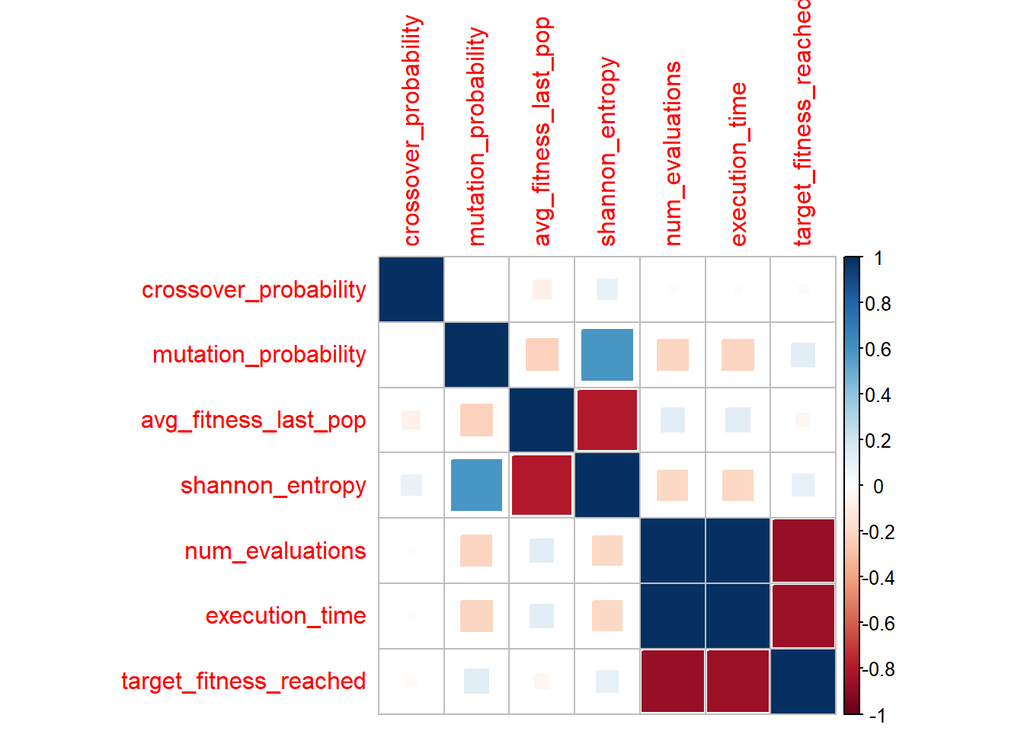

```r
corrplot(corr, method = "square")
```

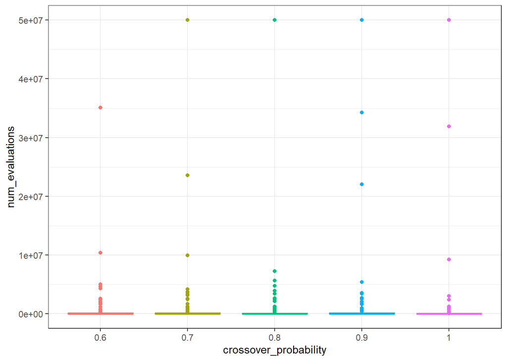

```r
df_study2_medium %>%
    mutate(crossover_probability = as.factor(crossover_probability)) %>%
    group_by(crossover_probability) %>%
    ggplot(mapping = aes(x = crossover_probability, y = num_evaluations, color=crossover_probability)) +
        geom_boxplot() +
        theme_bw() +
        theme(legend.position = "none")
```

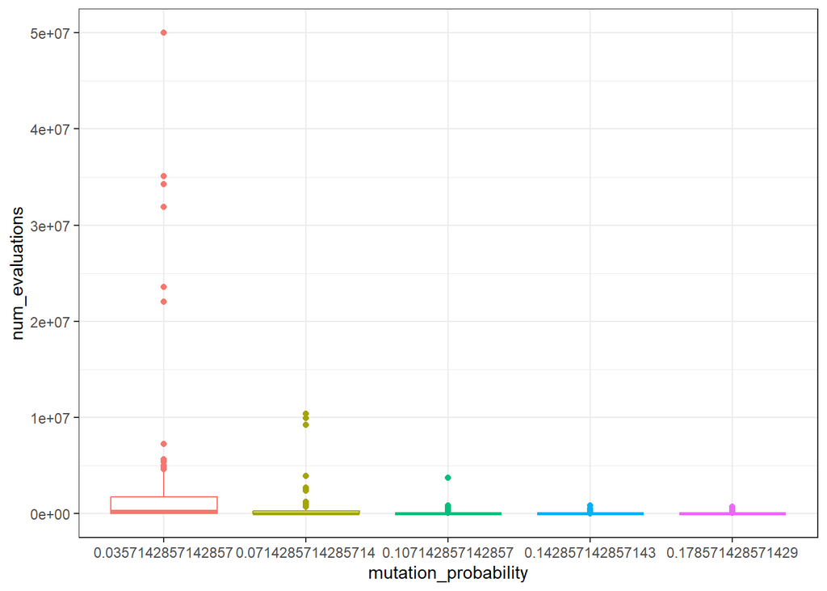

```r
df_study2_medium %>%
    mutate(mutation_probability = as.factor(mutation_probability)) %>%
    group_by(mutation_probability) %>%
    ggplot(mapping = aes(x = mutation_probability, y = num_evaluations, color=mutation_probability)) +
        geom_boxplot() +
        theme_bw() +
        theme(legend.position = "none")
```

As we can see, there are a number of outliers, in this case several trials where an abnormal (large) number of executions where required (in addition to those that did not reach the optimal), so let’s identify and filter some* of them in order to get a better visualization:

_(*we will not get them using the IQR method as we still want to retain as many as possible to show them in the chart, so we will set a manual limit of 1000000 evaluations)_

```r
df_study2_medium %>% filter(num_evaluations > 1000000)
```

| crossover_probability | mutation_probability | avg_fitness_last_pop | shannon_entropy | num_evaluations | execution_time | target_fitness_reached |
| --- | --- | --- | --- | --- | --- | --- |
| 0.6 | 0.03571429 | 12390.10 | 0.011541877 | 2089042 | 1.764 | TRUE |
| 0.6 | 0.03571429 | 12390.10 | 0.011541877 | 2613370 | 2.214 | TRUE |
| 0.6 | 0.03571429 | 12390.10 | 0.011541877 | 1774807 | 1.504 | TRUE |
| 0.6 | 0.03571429 | 12390.10 | 0.011541877 | 35107318 | 28.322 | TRUE |
| 0.6 | 0.03571429 | 12360.40 | 0.011541877 | 1613831 | 1.366 | TRUE |
| 0.6 | 0.03571429 | 12390.10 | 0.011541877 | 4610368 | 3.838 | TRUE |
| 0.6 | 0.03571429 | 12390.10 | 0.011541877 | 1184187 | 1.011 | TRUE |
| 0.6 | 0.03571429 | 12390.10 | 0.011541877 | 5008067 | 4.139 | TRUE |
| 0.6 | 0.03571429 | 12390.10 | 0.011541877 | 1883105 | 1.606 | TRUE |
| 0.6 | 0.03571429 | 12390.10 | 0.011541877 | 4342229 | 3.590 | TRUE |

[output cut: 53 more lines]

```r
df_study2_medium_outliers_grouped <- df_study2_medium %>%
  mutate(crossover_mutation = paste0(crossover_probability, ",", mutation_probability)) %>%
  group_by(crossover_mutation) %>%
  summarise(
    avg_num_evaluations = mean(num_evaluations),
    median_num_evaluations = median(num_evaluations),
    std_num_evaluations = sd(num_evaluations),
    count = sum(num_evaluations > 1000000),
    .groups = 'keep'
  ) %>%
  filter(count > 0)
df_study2_medium_outliers_grouped <- as.data.frame(df_study2_medium_outliers_grouped)
df_study2_medium_outliers_grouped
```

| crossover_mutation | avg_num_evaluations | median_num_evaluations | std_num_evaluations | count |
| --- | --- | --- | --- | --- |
| 0.6,0.0357142857142857 | 2092451.3 | 263657.0 | 6403463.6 | 10 |
| 0.6,0.0714285714285714 | 589741.7 | 108636.0 | 1906374.0 | 2 |
| 0.7,0.0357142857142857 | 4730964.7 | 416835.5 | 12587769.9 | 12 |
| 0.7,0.0714285714285714 | 522425.5 | 38355.5 | 1807855.5 | 1 |
| 0.7,0.107142857142857 | 195385.5 | 10162.0 | 686021.5 | 1 |
| 0.8,0.0357142857142857 | 2891984.7 | 582291.0 | 8930511.9 | 14 |
| 0.8,0.0714285714285714 | 357695.5 | 23791.0 | 840074.2 | 3 |
| 0.9,0.0357142857142857 | 5745302.8 | 553495.5 | 13541425.5 | 12 |
| 0.9,0.0714285714285714 | 244481.1 | 28934.5 | 516309.7 | 1 |
| 1,0.0357142857142857 | 2939663.5 | 25481.0 | 10430133.2 | 5 |

[output cut: 1 more lines]

If we do not show these extreme cases (`num_evaluations`> 1000000):

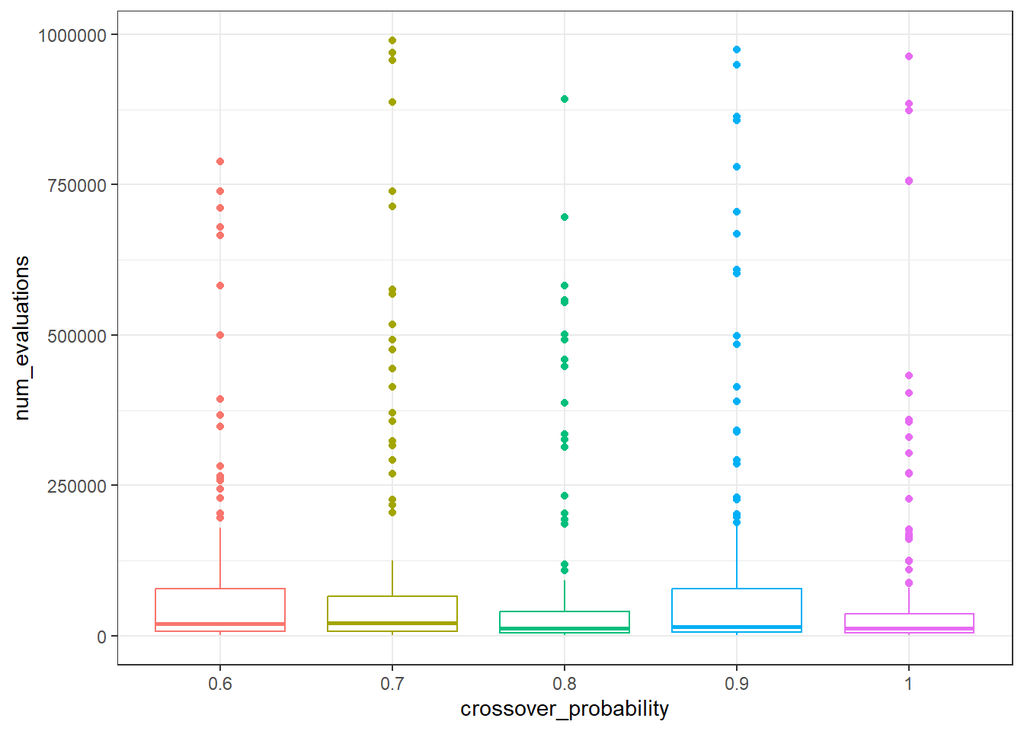

```r
df_study2_medium %>%
    filter(target_fitness_reached == TRUE, num_evaluations <= 1000000) %>%
    mutate(crossover_probability = as.factor(crossover_probability)) %>%
    group_by(crossover_probability) %>%
    ggplot(mapping = aes(x = crossover_probability, y = num_evaluations, color=crossover_probability)) +
        geom_boxplot() +
        theme_bw() +
        theme(legend.position = "none")
```

The same tendency that we saw in previous studies still holds: not only for extreme cases the crossover probability seems to not affect too much, but also in general it does not seem to have a clear effect on the number of evaluations. Let’s do the same with the mutation probability:

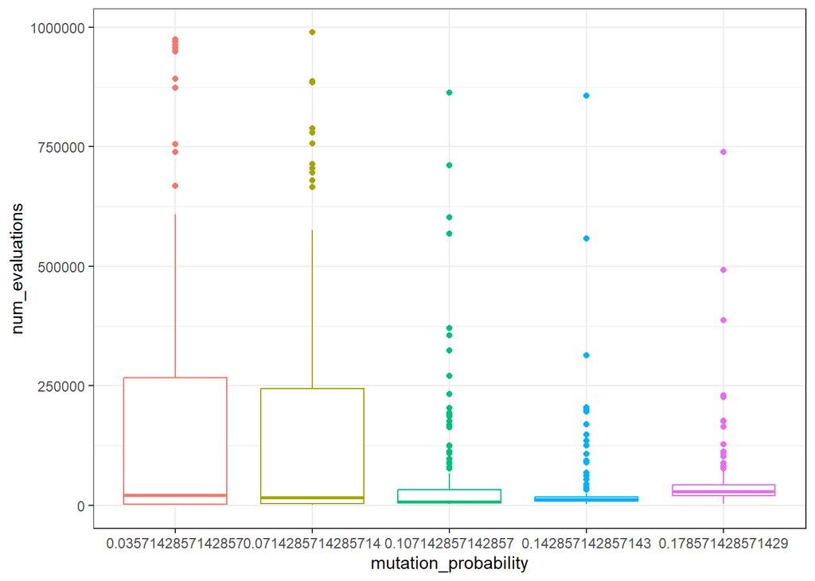

```r
df_study2_medium %>%
    filter(target_fitness_reached == TRUE, num_evaluations <= 1000000) %>%
    mutate(mutation_probability = as.factor(mutation_probability)) %>%
    group_by(mutation_probability) %>%
    ggplot(mapping = aes(x = mutation_probability, y = num_evaluations, color=mutation_probability)) +
        geom_boxplot() +
        theme_bw() +
        theme(legend.position = "none")
```

In contrast to the crossover probability, the mutation probability seems to have some effect on the number of evaluations, at least for smaller values it seems to be larger than when using greater mutation probability values. Let’s show them for each combination separately:

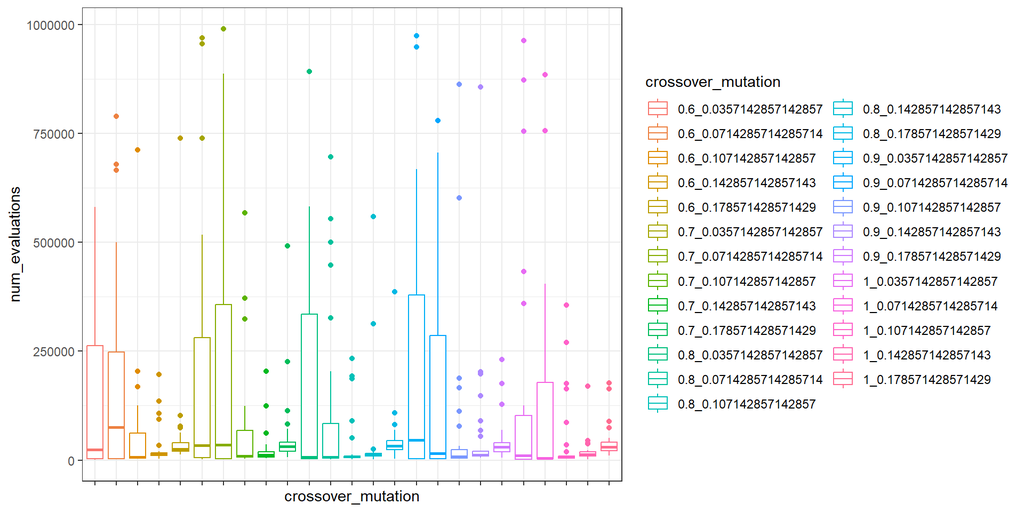

```r
df_study2_medium %>%
  filter(target_fitness_reached == TRUE, num_evaluations <= 1000000) %>%
  group_by(crossover_probability, mutation_probability) %>%
  mutate(crossover_mutation = paste0(crossover_probability, "_", mutation_probability)) %>%
  ggplot(mapping = aes(x = crossover_mutation, y = num_evaluations, color=crossover_mutation)) +
    geom_boxplot() +
    theme_bw() +
    scale_x_discrete(labels = NULL)
```

Now, let’s compute the mean/median/std number of evaluations (with all the observations):

```r
df_study2_medium_grouped <- df_study2_medium %>%
  mutate(crossover_mutation = paste0(crossover_probability, ",", mutation_probability)) %>%
  group_by(crossover_mutation) %>%
  summarise(
    avg_num_evaluations = mean(num_evaluations),
    median_num_evaluations = median(num_evaluations),
    std_num_evaluations = sd(num_evaluations),
    .groups = 'keep'
  )
df_study2_medium_grouped <- as.data.frame(df_study2_medium_grouped)
df_study2_medium_grouped
```

| crossover_mutation | avg_num_evaluations | median_num_evaluations | std_num_evaluations |
| --- | --- | --- | --- |
| 0.6,0.0357142857142857 | 2092451.27 | 263657.0 | 6403463.60 |
| 0.6,0.0714285714285714 | 589741.67 | 108636.0 | 1906373.96 |
| 0.6,0.107142857142857 | 58356.23 | 7080.5 | 134711.51 |
| 0.6,0.142857142857143 | 28776.13 | 12871.5 | 44458.30 |
| 0.6,0.178571428571429 | 56691.70 | 24751.5 | 130675.65 |
| 0.7,0.0357142857142857 | 4730964.66 | 416835.5 | 12587769.92 |
| 0.7,0.0714285714285714 | 522425.47 | 38355.5 | 1807855.50 |
| 0.7,0.107142857142857 | 195385.47 | 10162.0 | 686021.45 |
| 0.7,0.142857142857143 | 24474.00 | 11364.5 | 41337.41 |
| 0.7,0.178571428571429 | 55787.13 | 31755.0 | 92472.57 |

[output cut: 15 more lines]

Considering the balance between these three metrics, the (crossover=1, mutation=0.142857142857143) combination seems to be the best one, followed by (crossover=0.7, mutation=0.142857142857143). Let’s create the new variable combining the crossover and mutation probabilities to run the Kruskal-Wallis test:

```r
df_study2_medium <- as.data.frame(df_study2_medium %>%
  mutate(crossover_mutation = paste0(crossover_probability, ",", mutation_probability)))
df_study2_medium
```

| crossover_probability | mutation_probability | avg_fitness_last_pop | shannon_entropy | num_evaluations | execution_time | target_fitness_reached | crossover_mutation |
| --- | --- | --- | --- | --- | --- | --- | --- |
| 0.6 | 0.03571429 | 12390.10 | 0.011541877 | 282789 | 0.267 | TRUE | 0.6,0.0357142857142857 |
| 0.6 | 0.03571429 | 12317.30 | 0.106729742 | 2418 | 0.003 | TRUE | 0.6,0.0357142857142857 |
| 0.6 | 0.03571429 | 11951.85 | 0.378561614 | 946 | 0.001 | TRUE | 0.6,0.0357142857142857 |
| 0.6 | 0.03571429 | 12370.30 | 0.008656407 | 23971 | 0.023 | TRUE | 0.6,0.0357142857142857 |
| 0.6 | 0.03571429 | 12390.10 | 0.011541877 | 347719 | 0.310 | TRUE | 0.6,0.0357142857142857 |
| 0.6 | 0.03571429 | 12226.75 | 0.057997425 | 2992 | 0.003 | TRUE | 0.6,0.0357142857142857 |
| 0.6 | 0.03571429 | 12360.40 | 0.011541877 | 367178 | 0.309 | TRUE | 0.6,0.0357142857142857 |
| 0.6 | 0.03571429 | 12360.40 | 0.011541877 | 179287 | 0.148 | TRUE | 0.6,0.0357142857142857 |
| 0.6 | 0.03571429 | 12370.30 | 0.008656407 | 10935 | 0.011 | TRUE | 0.6,0.0357142857142857 |
| 0.6 | 0.03571429 | 12360.40 | 0.011541877 | 581750 | 0.497 | TRUE | 0.6,0.0357142857142857 |

[output cut: 746 more lines]

```r
# for (combination in levels(as.factor(df_study2_medium$crossover_mutation))) {
#   print(combination)
#   print(shapiro.test(
#     df_study2_medium[df_study2_medium$crossover_mutation == combination, 'num_evaluations']))
# }
```

```r
kruskal.test(num_evaluations ~ crossover_mutation, data = df_study2_medium)
```

```
##
##  Kruskal-Wallis rank sum test
##
## data:  num_evaluations by crossover_mutation
## Kruskal-Wallis chi-squared = 100.64, df = 24, p-value = 2.338e-11
```

The test gives us a p-value smaller than the 0.02 level of significance, so there’s at least a combination of parameters that does not belong to the same population distribution as the rest. Let’s apply the Wilcoxon test between each pair of combinations:

```r
result <- pairwise.wilcox.test(x = df_study2_medium$num_evaluations,
                               g = df_study2_medium$crossover_mutation,
                               p.adjust.method = "BH",
                               paired = FALSE)
print(result)
```

```
##
##  Pairwise comparisons using Wilcoxon rank sum exact test
##
## data:  df_study2_medium$num_evaluations and df_study2_medium$crossover_mutation
##
##                        0.6,0.0357142857142857 0.6,0.0714285714285714
## 0.6,0.0714285714285714 0.34616                -
## 0.6,0.107142857142857  0.01325                0.14270
## 0.6,0.142857142857143  0.01373                0.06294
## 0.6,0.178571428571429  0.08438                0.18201
## 0.7,0.0357142857142857 0.75260                0.11598
## 0.7,0.0714285714285714 0.23021                0.78181
## 0.7,0.107142857142857  0.07438                0.39857
## 0.7,0.142857142857143  0.01071                0.05188
## 0.7,0.178571428571429  0.10046                0.19716
## 0.8,0.0357142857142857 0.76228                0.10451
## 0.8,0.0714285714285714 0.14456                0.68124
## 0.8,0.107142857142857  0.00442                0.05752
## 0.8,0.142857142857143  0.00895                0.05913
## 0.8,0.178571428571429  0.14270                0.17313
## 0.9,0.0357142857142857 0.68124                0.12685
## 0.9,0.0714285714285714 0.14270                0.76228
## 0.9,0.107142857142857  0.01628                0.14456
## 0.9,0.142857142857143  0.02089                0.17313
## 0.9,0.178571428571429  0.08438                0.16990
## 1,0.0357142857142857   0.15707                0.58401
## 1,0.0714285714285714   0.08012                0.66384
## 1,0.107142857142857    0.00737                0.08690
## 1,0.142857142857143    0.00803                0.04150
## 1,0.178571428571429    0.09484                0.16146
##                        0.6,0.107142857142857 0.6,0.142857142857143
## 0.6,0.0714285714285714 -                     -
## 0.6,0.107142857142857  -                     -
## 0.6,0.142857142857143  0.17753               -
## 0.6,0.178571428571429  0.01514               0.00033
## 0.7,0.0357142857142857 0.00308               0.00259
## 0.7,0.0714285714285714 0.63492               0.50649
## 0.7,0.107142857142857  0.23419               0.95803
## 0.7,0.142857142857143  0.41401               0.58132
## 0.7,0.178571428571429  0.01461               0.00214
```

[output cut: 252 more lines]

```
## 0.8,0.107142857142857  -                   -
## 0.8,0.142857142857143  -                   -
## 0.8,0.178571428571429  -                   -
## 0.9,0.0357142857142857 -                   -
## 0.9,0.0714285714285714 -                   -
## 0.9,0.107142857142857  -                   -
## 0.9,0.142857142857143  -                   -
## 0.9,0.178571428571429  -                   -
## 1,0.0357142857142857   -                   -
## 1,0.0714285714285714   -                   -
## 1,0.107142857142857    -                   -
## 1,0.142857142857143    0.02137             -
## 1,0.178571428571429    0.00030             0.00030
##
## P value adjustment method: BH
```

```r
GetNumberDifferentPairs(result, 0.02)
```

```
## [1] "Number of different pairs: 77"
```

We can see that, for example, the two combinations that we considered the best by looking at the three computed statistics can be considered as having the same median since the p-value is 0.69823, which is not smaller than 0.02 and thus for that pair the null hypothesis cannot be rejected.

Let’s test crossover and mutation probabilities separately:

```r
df_study2_medium_grouped_crossover <- df_study2_medium %>%
  group_by(crossover_probability) %>%
  summarise(
    avg_num_evaluations = mean(num_evaluations),
    median_num_evaluations = median(num_evaluations),
    std_num_evaluations = sd(num_evaluations),
    .groups = 'keep'
  )
df_study2_medium_grouped_crossover <- as.data.frame(df_study2_medium_grouped_crossover)
df_study2_medium_grouped_crossover
```

| crossover_probability | avg_num_evaluations | median_num_evaluations | std_num_evaluations |
| --- | --- | --- | --- |
| 0.6 | 565203.4 | 22738.5 | 3053975 |
| 0.7 | 1153506.8 | 28087.0 | 6059397 |
| 0.8 | 688293.5 | 15854.0 | 4167666 |
| 0.9 | 1293360.9 | 19307.5 | 6560056 |
| 1.0 | 724492.6 | 14475.0 | 4861923 |

```r
df_study2_medium_grouped_mutation <- df_study2_medium %>%
  group_by(mutation_probability) %>%
  summarise(
    avg_num_evaluations = mean(num_evaluations),
    median_num_evaluations = median(num_evaluations),
    std_num_evaluations = sd(num_evaluations),
    .groups = 'keep'
  )
df_study2_medium_grouped_mutation <- as.data.frame(df_study2_medium_grouped_mutation)
df_study2_medium_grouped_mutation
```

| mutation_probability | avg_num_evaluations | median_num_evaluations | std_num_evaluations |
| --- | --- | --- | --- |
| 0.03571429 | 3710225.59 | 276023.0 | 10693806.60 |
| 0.07142857 | 444193.84 | 34802.0 | 1456551.40 |
| 0.10714286 | 80012.59 | 7574.0 | 328296.09 |
| 0.14285714 | 35075.71 | 12239.0 | 92417.56 |
| 0.17857143 | 48983.88 | 28504.5 | 81903.15 |

```r
kruskal.test(num_evaluations ~ crossover_probability, data = df_study2_medium)
```

```
##
##  Kruskal-Wallis rank sum test
##
## data:  num_evaluations by crossover_probability
## Kruskal-Wallis chi-squared = 9.7766, df = 4, p-value = 0.04436
```

Given the 0.02 level of significance, there is not enough statistical evidence to reject that all the samples come from the same population distribution when using different crossover probabilities. Let’s check the mutation probability:

```r
kruskal.test(num_evaluations ~ mutation_probability, data = df_study2_medium)
```

```
##
##  Kruskal-Wallis rank sum test
##
## data:  num_evaluations by mutation_probability
## Kruskal-Wallis chi-squared = 78.281, df = 4, p-value = 4.027e-16
```

The p-value is smaller than 0.02 so there’s at least one mutation probability that yields a different number of evaluations than the rest, let’s check it:

```r
pairwise.wilcox.test(x = df_study2_medium$num_evaluations,
                     g = df_study2_medium$mutation_probability,
                     p.adjust.method = "BH",
                     paired = FALSE)
```

```
##
##  Pairwise comparisons using Wilcoxon rank sum test with continuity correction
##
## data:  df_study2_medium$num_evaluations and df_study2_medium$mutation_probability
##
##                    0.0357142857142857 0.0714285714285714 0.107142857142857
## 0.0714285714285714 0.00041            -                  -
## 0.107142857142857  5.4e-08            0.19416            -
## 0.142857142857143  1.7e-08            0.24302            0.00059
## 0.178571428571429  8.2e-05            0.85687            6.7e-12
##                    0.142857142857143
## 0.0714285714285714 -
## 0.107142857142857  -
## 0.142857142857143  -
## 0.178571428571429  < 2e-16
##
## P value adjustment method: BH
```

According to the results of this test, there is not enough evidence to reject that the median number of evaluations of 0.0714285714285714 with respect to 0.107142857142857, 0.142857142857143 and 0.178571428571429 is different to that of those, respectively. Besides these 3 pairs, the rest of pairs yields different results between each other. Looking at the balance between mean, median and std, we could say that the best option among the tested values is a mutation probability of 0.142857142857143.

## Large problem size

As we mentioned for the medium-sized problem instance, there can be some executions that do not reach the target fitness within a maximum number of evaluations. In the previous instance, we included those evaluations in the study as they were negligible (only 6 out of 756 total executions). However, as we will see in the next sections, that has not been the case with the large problem instance. Thus, we divide the study in two sub-studies: one strictly for reaching the optimal, and another for a relaxation of that optimal (99.5% and 99%).

```r
df_study2_large <- filter(df_study2, problem_index == 6)
str(df_study2_large)
```

```
## 'data.frame':    2765 obs. of  13 variables:
##  $ problem_index        : int  6 6 6 6 6 6 6 6 6 6 ...
##  $ population_size      : int  200 200 200 200 200 200 200 200 200 200 ...
##  $ crossover_probability: num  0.6 0.6 0.6 0.6 0.6 0.6 0.6 0.6 0.6 0.6 ...
##  $ mutation_probability : num  0.02 0.02 0.02 0.02 0.02 0.02 0.02 0.02 0.02 0.02 ...
##  $ search_optimal       : int  1 1 1 1 1 1 1 1 1 1 ...
##  $ max_steps            : int  1000000 1000000 1000000 1000000 1000000 1000000 1000000 1000000 1000000 1000000 ...
##  $ optimal_fitness      : num  16537 16537 16537 16537 16537 ...
##  $ optimal_percentage   : num  100 100 100 100 100 100 100 100 100 100 ...
##  $ best_fitness_last_pop: num  16381 16455 16518 16537 16537 ...
##  $ avg_fitness_last_pop : num  16381 16455 16435 16524 16524 ...
##  $ shannon_entropy      : num  0 0 0.00182 0.00363 0.00363 ...
##  $ num_evaluations      : int  50000000 50000000 50000000 4722373 19033035 50000000 50000000 50000000 10458032 11873906 ...
##  $ execution_time       : num  66.22 65.96 66.04 6.28 25.34 ...
```

Before doing each study, we will create the new variable that indicates whether the target fitness (optimal or the specified percentage of it was reached):

```r
df_study2_large <- ComputeTargetFitnessReached(df_study2_large)
```

```
##    Mode   FALSE    TRUE
## logical     516    2249
```

### Search for optimal

```r
df_study2_large_optimal <- filter(df_study2_large, optimal_percentage == 100.0)
str(df_study2_large_optimal)
```

```
## 'data.frame':    1185 obs. of  14 variables:
##  $ problem_index         : int  6 6 6 6 6 6 6 6 6 6 ...
##  $ population_size       : int  200 200 200 200 200 200 200 200 200 200 ...
##  $ crossover_probability : num  0.6 0.6 0.6 0.6 0.6 0.6 0.6 0.6 0.6 0.6 ...
##  $ mutation_probability  : num  0.02 0.02 0.02 0.02 0.02 0.02 0.02 0.02 0.02 0.02 ...
##  $ search_optimal        : int  1 1 1 1 1 1 1 1 1 1 ...
##  $ max_steps             : int  1000000 1000000 1000000 1000000 1000000 1000000 1000000 1000000 1000000 1000000 ...
##  $ optimal_fitness       : num  16537 16537 16537 16537 16537 ...
##  $ optimal_percentage    : num  100 100 100 100 100 100 100 100 100 100 ...
##  $ best_fitness_last_pop : num  16381 16455 16518 16537 16537 ...
##  $ avg_fitness_last_pop  : num  16381 16455 16435 16524 16524 ...
##  $ shannon_entropy       : num  0 0 0.00182 0.00363 0.00363 ...
##  $ num_evaluations       : int  50000000 50000000 50000000 4722373 19033035 50000000 50000000 50000000 10458032 11873906 ...
##  $ execution_time        : num  66.22 65.96 66.04 6.28 25.34 ...
##  $ target_fitness_reached: logi  FALSE FALSE FALSE TRUE TRUE FALSE ...
```

As we can see, there are 435 additional executions which indicates that there are as many as that number of executions in which the algorithm was not able to reach the optimal fitness.

```r
summary(df_study2_large_optimal[, colnames(df_study2_large_optimal) %in% columns_to_drop])
```

```
##  problem_index population_size search_optimal   max_steps     optimal_fitness
##  Min.   :6     Min.   :200     Min.   :1      Min.   :1e+06   Min.   :16537
##  1st Qu.:6     1st Qu.:200     1st Qu.:1      1st Qu.:1e+06   1st Qu.:16537
##  Median :6     Median :200     Median :1      Median :1e+06   Median :16537
##  Mean   :6     Mean   :200     Mean   :1      Mean   :1e+06   Mean   :16537
##  3rd Qu.:6     3rd Qu.:200     3rd Qu.:1      3rd Qu.:1e+06   3rd Qu.:16537
##  Max.   :6     Max.   :200     Max.   :1      Max.   :1e+06   Max.   :16537
##  optimal_percentage best_fitness_last_pop
##  Min.   :100        Min.   :16330
##  1st Qu.:100        1st Qu.:16518
##  Median :100        Median :16537
##  Mean   :100        Mean   :16517
##  3rd Qu.:100        3rd Qu.:16537
##  Max.   :100        Max.   :16537
```

```r
df_study2_large_optimal <- DropColumns(df_study2_large_optimal, columns_to_drop)
```

```
## [1] "crossover_probability"  "mutation_probability"   "avg_fitness_last_pop"
## [4] "shannon_entropy"        "num_evaluations"        "execution_time"
## [7] "target_fitness_reached"
```

```r
corr <- cor(df_study2_large_optimal)
corr
```

```
##                        crossover_probability mutation_probability
## crossover_probability             1.00000000          -0.05871050
## mutation_probability             -0.05871050           1.00000000
## avg_fitness_last_pop             -0.04835795           0.08755388
## shannon_entropy                   0.03817223           0.63688404
## num_evaluations                   0.03743275          -0.51316031
## execution_time                    0.03351215          -0.49940947
## target_fitness_reached           -0.06433929           0.42016945
##                        avg_fitness_last_pop shannon_entropy num_evaluations
## crossover_probability           -0.04835795      0.03817223      0.03743275
## mutation_probability             0.08755388      0.63688404     -0.51316031
## avg_fitness_last_pop             1.00000000     -0.16890405     -0.44145209
## shannon_entropy                 -0.16890405      1.00000000     -0.54982359
## num_evaluations                 -0.44145209     -0.54982359      1.00000000
## execution_time                  -0.43880269     -0.54919967      0.99952372
## target_fitness_reached           0.51758827      0.47010970     -0.94762385
##                        execution_time target_fitness_reached
## crossover_probability      0.03351215            -0.06433929
## mutation_probability      -0.49940947             0.42016945
## avg_fitness_last_pop      -0.43880269             0.51758827
## shannon_entropy           -0.54919967             0.47010970
## num_evaluations            0.99952372            -0.94762385
## execution_time             1.00000000            -0.94777959
## target_fitness_reached    -0.94777959             1.00000000
```

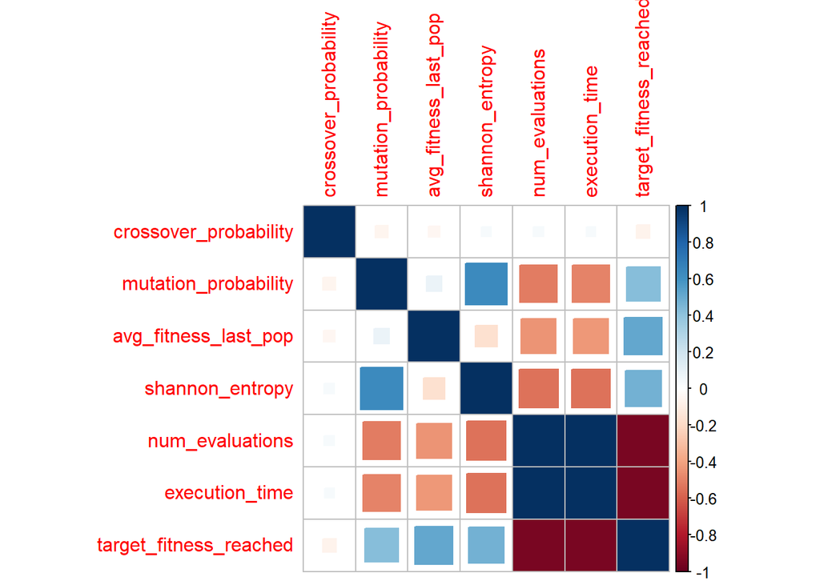

```r
corrplot(corr, method = "square")
```

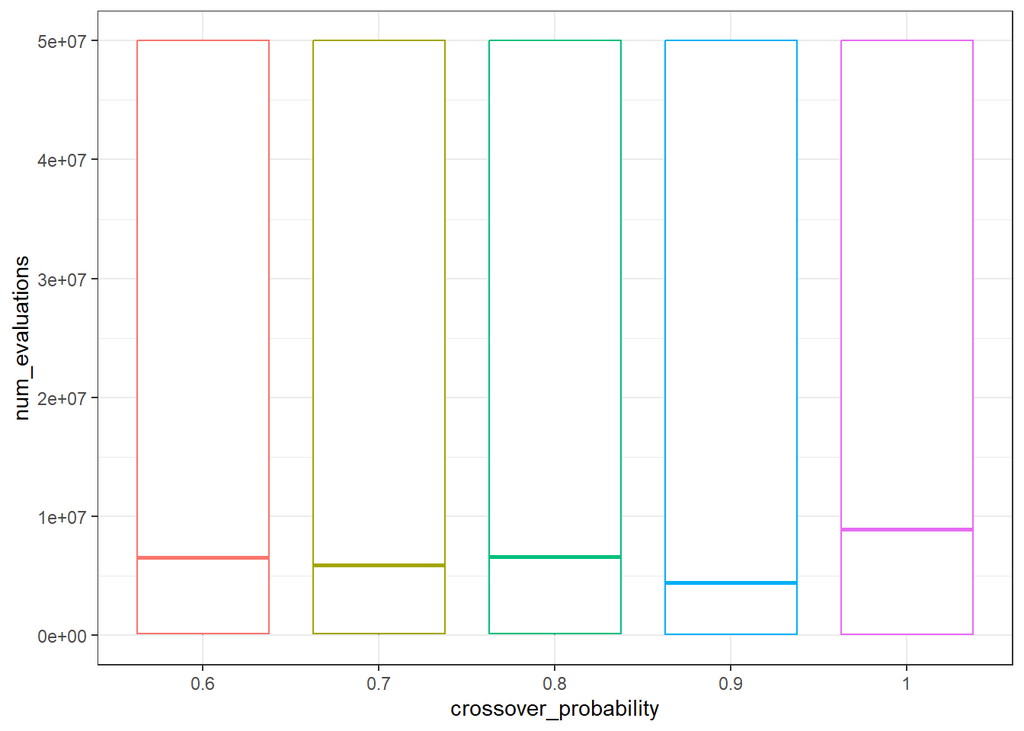

```r
df_study2_large_optimal %>%
    mutate(crossover_probability = as.factor(crossover_probability)) %>%
    group_by(crossover_probability) %>%
    ggplot(mapping = aes(x = crossover_probability, y = num_evaluations, color=crossover_probability)) +
        geom_boxplot() +
        theme_bw() +
        theme(legend.position = "none")
```

Again, the crossover probability does not seem to have a clear effect on the number of executions.

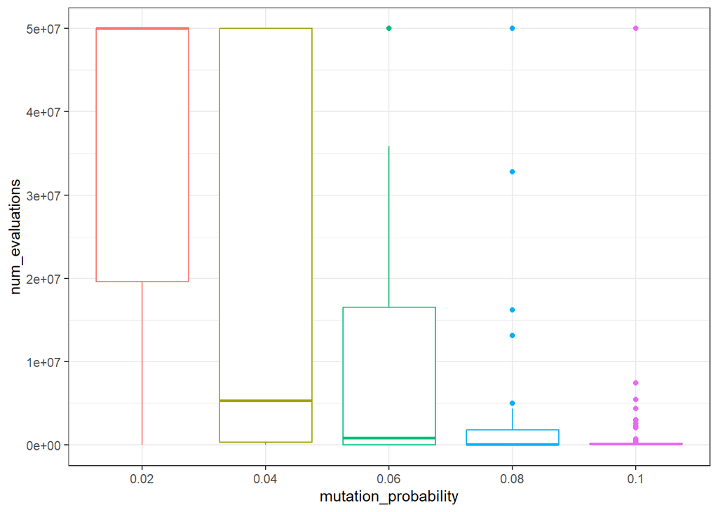

```r
df_study2_large_optimal %>%
    mutate(mutation_probability = as.factor(mutation_probability)) %>%
    group_by(mutation_probability) %>%
    ggplot(mapping = aes(x = mutation_probability, y = num_evaluations, color=mutation_probability)) +
        geom_boxplot() +
        theme_bw() +
        theme(legend.position = "none")
```

Regarding the mutation probability, the same pattern we saw in the first study with the obtained fitness also holds for the number of evaluations, in the sense that a higher value yields better results (a smaller number of evaluations).

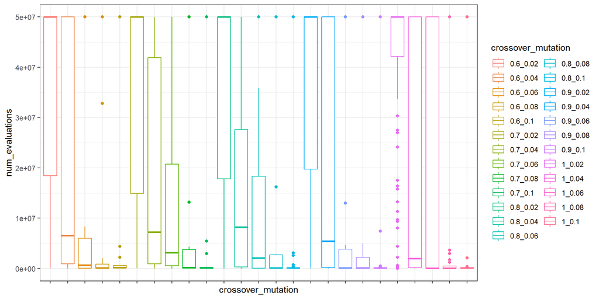

```r
df_study2_large_optimal %>%
  group_by(crossover_probability, mutation_probability) %>%
  mutate(crossover_mutation = paste0(crossover_probability, "_", mutation_probability)) %>%
  ggplot(mapping = aes(x = crossover_mutation, y = num_evaluations, color=crossover_mutation)) +
    geom_boxplot() +
    theme_bw() +
    scale_x_discrete(labels = NULL)
```

Let’s compute the mean, median and standard deviation of the number of evaluations and how many times the optimal was not reached out of the total number of executions for each combination of parameters (**taking into account that we executed each combination until we obtained 30 executions where the optimal was reached**):

```r
df_study2_large_optimal_grouped <- df_study2_large_optimal %>%
  mutate(crossover_mutation = paste0(crossover_probability, ",", mutation_probability)) %>%
  group_by(crossover_mutation) %>%
  summarise(
    avg_num_evaluations = mean(num_evaluations),
    median_num_evaluations = median(num_evaluations),
    std_num_evaluations = sd(num_evaluations),
    optimal_not_reached = sum(target_fitness_reached == FALSE),
    .groups = 'keep'
  )
df_study2_large_optimal_grouped <- as.data.frame(df_study2_large_optimal_grouped)
df_study2_large_optimal_grouped
```

| crossover_mutation | avg_num_evaluations | median_num_evaluations | std_num_evaluations | optimal_not_reached |
| --- | --- | --- | --- | --- |
| 0.6,0.02 | 37244284 | 50000000.0 | 18765202 | 56 |
| 0.6,0.04 | 18231935 | 6584120.0 | 21047003 | 11 |
| 0.6,0.06 | 11751755 | 680713.0 | 20123770 | 8 |
| 0.6,0.08 | 8292250 | 100228.0 | 18132152 | 5 |
| 0.6,0.1 | 9764883 | 159340.0 | 19718534 | 7 |
| 0.7,0.02 | 35189968 | 50000000.0 | 20037486 | 40 |
| 0.7,0.04 | 18775884 | 7240903.5 | 20861134 | 10 |
| 0.7,0.06 | 14767735 | 3138194.0 | 19609664 | 8 |
| 0.7,0.08 | 11245637 | 185598.0 | 20400458 | 8 |
| 0.7,0.1 | 6235968 | 131240.0 | 16252799 | 4 |

[output cut: 15 more lines]

As we can see, it seems that most of the executions where the optimal was not reached correspond to using the smallest tested mutation probability (0.02). Also, we had such cases for every tested combination.

We can check that count for grouped by crossover and mutation probabilities, separately:

```r
df_study2_large_optimal_grouped_crossover <- df_study2_large_optimal %>%
  group_by(crossover_probability) %>%
  summarise(
    avg_num_evaluations = mean(num_evaluations),
    median_num_evaluations = median(num_evaluations),
    std_num_evaluations = sd(num_evaluations),
    optimal_not_reached = sum(target_fitness_reached == FALSE),
    .groups = 'keep'
  )
df_study2_large_optimal_grouped_crossover <- as.data.frame(df_study2_large_optimal_grouped_crossover)
df_study2_large_optimal_grouped_crossover
```

| crossover_probability | avg_num_evaluations | median_num_evaluations | std_num_evaluations | optimal_not_reached |
| --- | --- | --- | --- | --- |
| 0.6 | 21302168 | 6584120 | 22956158 | 87 |
| 0.7 | 20067565 | 5932287 | 22373306 | 70 |
| 0.8 | 20237054 | 6639278 | 22300785 | 70 |
| 0.9 | 20601409 | 4429462 | 23303385 | 88 |
| 1.0 | 23849579 | 8899853 | 24059658 | 120 |

We can see that a crossover probability of 1.0 seems to yield more executions where the optimal was not reached, but the difference comparing with the rest of values is not huge, there isn’t a clear pattern. Let’s group by mutation probability:

```r
df_study2_large_optimal_grouped_mutation <- df_study2_large_optimal %>%
  group_by(mutation_probability) %>%
  summarise(
    avg_num_evaluations = mean(num_evaluations),
    median_num_evaluations = median(num_evaluations),
    std_num_evaluations = sd(num_evaluations),
    optimal_not_reached = sum(target_fitness_reached == FALSE),
    .groups = 'keep'
  )
df_study2_large_optimal_grouped_mutation <- as.data.frame(df_study2_large_optimal_grouped_mutation)
df_study2_large_optimal_grouped_mutation
```

| mutation_probability | avg_num_evaluations | median_num_evaluations | std_num_evaluations | optimal_not_reached |
| --- | --- | --- | --- | --- |
| 0.02 | 37458362 | 50000000.0 | 19149104 | 291 |
| 0.04 | 17591707 | 5339755.0 | 21035291 | 53 |
| 0.06 | 12450229 | 830130.0 | 19674635 | 38 |
| 0.08 | 9035295 | 105109.5 | 18605124 | 30 |
| 0.10 | 6941623 | 134955.0 | 16931259 | 23 |

In contrast to the crossover probability, for the mutation probability there’s a value which clearly stands out as not very suitable to reach the optimal fitness, and that’s the smallest tested value, 0.02. It seems that the higher the mutation probability (in the tested range of values), the less probable that we do not reach the optimal.

**Directly comparing the different samples may not be a good strategy if we do not filter those cases where we do not reach the optimal, as those samples may have a different number of executions (for example, 30 executions where the optimal was reached + 56 where it was not reached for a total of 86 executions where carried out for the 0.6,0.02 combination, while for others, for example 1.0,0.08, the number of executions is considerably smaller, 33 in that case). Thus, we will filter such cases, so that for each combination we will have 30 executions. In the next subsection, we will carry out a fairer comparison as we will relax the target fitness to be a slightly smaller percentage of the optimal fitness.**

```r
df_study2_large_optimal <- as.data.frame(df_study2_large_optimal %>%
  mutate(crossover_mutation = paste0(crossover_probability, ",", mutation_probability))) %>%
  filter(target_fitness_reached == TRUE)
df_study2_large_optimal
```

| crossover_probability | mutation_probability | avg_fitness_last_pop | shannon_entropy | num_evaluations | execution_time | target_fitness_reached | crossover_mutation |
| --- | --- | --- | --- | --- | --- | --- | --- |
| 0.6 | 0.02 | 16524.06 | 0.003633175 | 4722373 | 6.282 | TRUE | 0.6,0.02 |
| 0.6 | 0.02 | 16524.06 | 0.003633175 | 19033035 | 25.343 | TRUE | 0.6,0.02 |
| 0.6 | 0.02 | 16516.10 | 0.001816588 | 10458032 | 13.853 | TRUE | 0.6,0.02 |
| 0.6 | 0.02 | 16524.06 | 0.003633175 | 11873906 | 15.721 | TRUE | 0.6,0.02 |
| 0.6 | 0.02 | 16516.10 | 0.001816588 | 62843 | 0.079 | TRUE | 0.6,0.02 |
| 0.6 | 0.02 | 16521.08 | 0.001816588 | 4535915 | 6.041 | TRUE | 0.6,0.02 |
| 0.6 | 0.02 | 16524.06 | 0.003633175 | 12590516 | 16.683 | TRUE | 0.6,0.02 |
| 0.6 | 0.02 | 16524.06 | 0.003633175 | 10042109 | 13.319 | TRUE | 0.6,0.02 |
| 0.6 | 0.02 | 16524.06 | 0.003633175 | 13941915 | 18.466 | TRUE | 0.6,0.02 |
| 0.6 | 0.02 | 16524.06 | 0.003633175 | 30503673 | 40.281 | TRUE | 0.6,0.02 |

[output cut: 740 more lines]

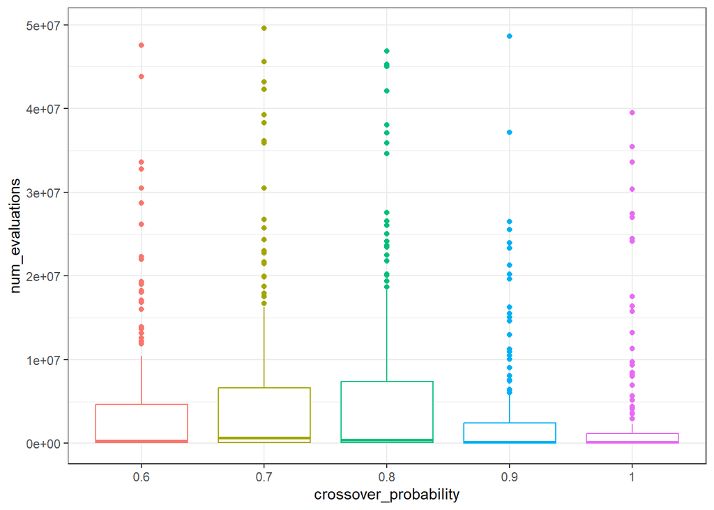

```r
df_study2_large_optimal %>%
    mutate(crossover_probability = as.factor(crossover_probability)) %>%
    group_by(crossover_probability) %>%
    ggplot(mapping = aes(x = crossover_probability, y = num_evaluations, color=crossover_probability)) +
        geom_boxplot() +
        theme_bw() +
        theme(legend.position = "none")
```

It seems that if do not consider the ‘unfinished’ executions, the crossover probability seems to have some influence in the dispersion of the number of evaluations (we can see that the 3rd quartile is smaller with a value of 0.9 and 0.1, but there is no clear pattern as between 0.6 and 0.8 it seems to increase); still, the median seems to be very similar for all of the tested values.

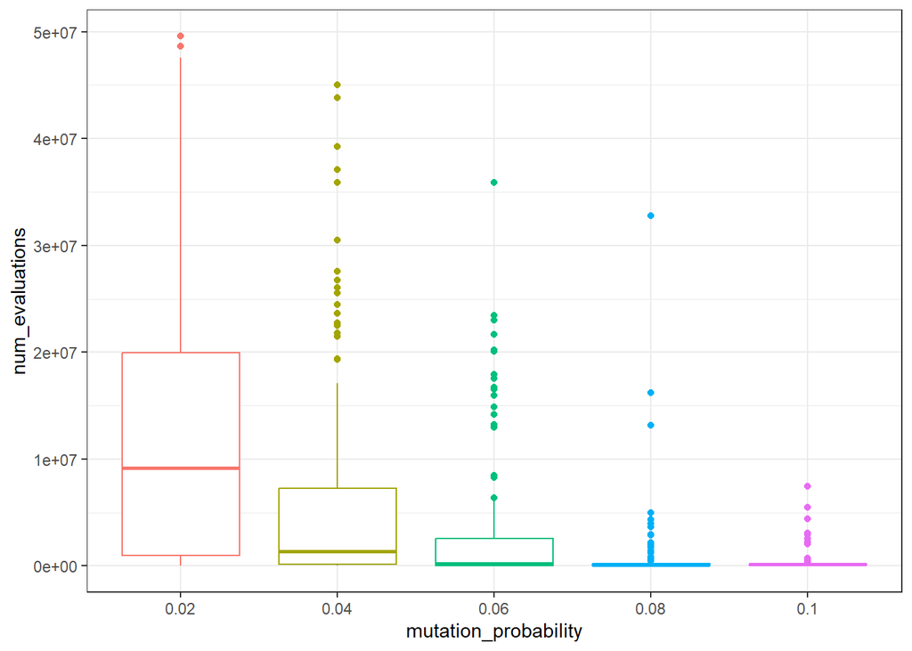

```r
df_study2_large_optimal %>%
    mutate(mutation_probability = as.factor(mutation_probability)) %>%
    group_by(mutation_probability) %>%
    ggplot(mapping = aes(x = mutation_probability, y = num_evaluations, color=mutation_probability)) +
        geom_boxplot() +
        theme_bw() +
        theme(legend.position = "none")
```

The same effect that when considering the ‘unfinished’ executions can be observed with the mutation probability: one might say that the higher the value (in the tested range), the better.

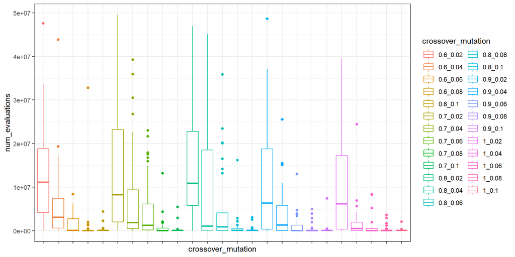

```r
df_study2_large_optimal %>%
  group_by(crossover_probability, mutation_probability) %>%
  mutate(crossover_mutation = paste0(crossover_probability, "_", mutation_probability)) %>%
  ggplot(mapping = aes(x = crossover_mutation, y = num_evaluations, color=crossover_mutation)) +
    geom_boxplot() +
    theme_bw() +
    scale_x_discrete(labels = NULL)
```

```r
# for (combination in levels(as.factor(df_study2_large_optimal$crossover_mutation))) {
#   print(combination)
#   print(shapiro.test(
#     df_study2_large_optimal[df_study2_large_optimal$crossover_mutation == combination, 'num_evaluations']))
# }
```

Now let’s execute the Kruskal-Wallis test:

```r
kruskal.test(num_evaluations ~ crossover_mutation, data = df_study2_large_optimal)
```

```
##
##  Kruskal-Wallis rank sum test
##
## data:  num_evaluations by crossover_mutation
## Kruskal-Wallis chi-squared = 222.11, df = 24, p-value < 2.2e-16
```

The test gives us a p-value smaller than the 0.02 level of significance, so there’s at least a combination of parameters that does not belong to the same population distribution as the rest. Let’s apply the Wilcoxon test between each pair of combinations:

```r
result <- pairwise.wilcox.test(x = df_study2_large_optimal$num_evaluations,
                               g = df_study2_large_optimal$crossover_mutation,
                               p.adjust.method = "BH",
                               paired = FALSE)
print(result)
```

```
##
##  Pairwise comparisons using Wilcoxon rank sum exact test
##
## data:  df_study2_large_optimal$num_evaluations and df_study2_large_optimal$crossover_mutation
##
##          0.6,0.02 0.6,0.04 0.6,0.06 0.6,0.08 0.6,0.1 0.7,0.02 0.7,0.04 0.7,0.06
## 0.6,0.04 0.00661  -        -        -        -       -        -        -
## 0.6,0.06 2.0e-07  0.00481  -        -        -       -        -        -
## 0.6,0.08 1.8e-08  2.1e-05  0.37635  -        -       -        -        -
## 0.6,0.1  1.5e-08  1.8e-05  0.97725  0.00638  -       -        -        -
## 0.7,0.02 0.96131  0.03795  2.4e-06  3.1e-08  2.7e-08 -        -        -
## 0.7,0.04 0.01867  0.91664  0.01375  0.00053  0.00016 0.07095  -        -
## 0.7,0.06 0.00170  0.47243  0.05371  0.00503  0.00545 0.00616  0.46641  -
## 0.7,0.08 1.8e-08  0.00015  0.66420  0.67060  0.23552 7.8e-08  0.00189  0.01375
## 0.7,0.1  1.5e-08  7.4e-06  0.73028  0.09857  0.24087 1.5e-08  0.00016  0.00380
## 0.8,0.02 0.96669  0.01622  2.4e-06  1.8e-07  2.9e-08 0.96873  0.05548  0.00521
## 0.8,0.04 0.05694  1.00000  0.05694  0.01420  0.00906 0.08873  0.77480  0.69858
## 0.8,0.06 0.00128  0.31874  0.21689  0.05371  0.08163 0.00440  0.31874  0.69471
## 0.8,0.08 1.8e-08  0.00014  0.57051  0.77480  0.08615 1.5e-07  0.00128  0.00977
## 0.8,0.1  1.5e-08  1.4e-05  0.89896  0.00595  0.96669 1.8e-08  0.00016  0.00661
## 0.9,0.02 0.20891  0.41553  0.00080  7.5e-05  1.7e-05 0.24629  0.59608  0.18536
## 0.9,0.04 0.00012  0.16138  0.31874  0.10381  0.11551 0.00067  0.21689  0.45087
## 0.9,0.06 1.8e-08  0.00071  0.33830  0.56200  0.12948 1.7e-07  0.00263  0.00977
## 0.9,0.08 1.5e-08  2.6e-05  0.36937  1.00000  0.01867 1.6e-08  0.00060  0.00569
## 0.9,0.1  1.5e-08  6.9e-06  0.60245  0.08615  0.14326 1.6e-08  7.5e-05  0.00199
## 1,0.02   0.20891  0.63303  0.00481  7.8e-05  0.00014 0.22096  0.73918  0.35562
## 1,0.04   5.8e-07  0.01754  0.90781  0.16138  0.25625 2.4e-05  0.03055  0.11293
## 1,0.06   7.4e-09  6.1e-05  0.15091  0.06226  0.00906 2.7e-08  0.00053  0.00096
## 1,0.08   7.4e-09  1.2e-05  0.31874  0.67060  0.00906 1.5e-08  0.00033  0.00292
## 1,0.1    1.5e-08  3.7e-06  0.67700  0.03795  0.31636 1.5e-08  6.1e-05  0.00161
##          0.7,0.08 0.7,0.1 0.8,0.02 0.8,0.04 0.8,0.06 0.8,0.08 0.8,0.1 0.9,0.02
## 0.6,0.04 -        -       -        -        -        -        -       -
## 0.6,0.06 -        -       -        -        -        -        -       -
## 0.6,0.08 -        -       -        -        -        -        -       -
## 0.6,0.1  -        -       -        -        -        -        -       -
## 0.7,0.02 -        -       -        -        -        -        -       -
## 0.7,0.04 -        -       -        -        -        -        -       -
## 0.7,0.06 -        -       -        -        -        -        -       -
## 0.7,0.08 -        -       -        -        -        -        -       -
## 0.7,0.1  0.46641  -       -        -        -        -        -       -
```

[output cut: 27 more lines]

```
## 0.8,0.06 -        -        -        -       -       -       -       -
## 0.8,0.08 -        -        -        -       -       -       -       -
## 0.8,0.1  -        -        -        -       -       -       -       -
## 0.9,0.02 -        -        -        -       -       -       -       -
## 0.9,0.04 -        -        -        -       -       -       -       -
## 0.9,0.06 0.10381  -        -        -       -       -       -       -
## 0.9,0.08 0.09857  0.56200  -        -       -       -       -       -
## 0.9,0.1  0.09136  0.22096  0.11551  -       -       -       -       -
## 1,0.02   0.06425  0.00067  7.8e-05  2.3e-05 -       -       -       -
## 1,0.04   0.36246  0.35027  0.20500  0.15809 0.02015 -       -       -
## 1,0.06   0.05371  0.50009  0.09355  0.02015 0.00016 0.15485 -       -
## 1,0.08   0.07922  0.75966  0.67700  0.07922 5.9e-05 0.13590 0.12203 -
## 1,0.1    0.07922  0.18902  0.06032  0.56200 3.0e-05 0.13233 0.01375 0.03795
##
## P value adjustment method: BH
```

```r
GetNumberDifferentPairs(result, 0.02)
```

```
## [1] "Number of different pairs: 141"
```

Let’s group by crossover probabilities, then mutation probabilities, separately:

```r
kruskal.test(num_evaluations ~ crossover_probability, data = df_study2_large_optimal)
```

```
##
##  Kruskal-Wallis rank sum test
##
## data:  num_evaluations by crossover_probability
## Kruskal-Wallis chi-squared = 24.147, df = 4, p-value = 7.462e-05
```

As we mentioned before, it seems that the crossover in this case actually has some influence on the number of evaluations, as the obtained p-value is smaller than the 0.02 level of significance which means that at least one value yields different results compared to the rest. Let’s check it with the Wilcoxon test:

```r
pairwise.wilcox.test(x = df_study2_large_optimal$num_evaluations,
                     g = df_study2_large_optimal$crossover_probability,
                     p.adjust.method = "BH",
                     paired = FALSE)
```

```
##
##  Pairwise comparisons using Wilcoxon rank sum test with continuity correction
##
## data:  df_study2_large_optimal$num_evaluations and df_study2_large_optimal$crossover_probability
##
##     0.6    0.7    0.8    0.9
## 0.7 0.5832 -      -      -
## 0.8 0.6801 0.7338 -      -
## 0.9 0.0308 0.0050 0.0142 -
## 1   0.0045 0.0013 0.0036 0.5832
##
## P value adjustment method: BH
```

```r
df_study2_large_optimal_grouped_crossover <- df_study2_large_optimal %>%
  group_by(crossover_probability) %>%
  summarise(
    avg_num_evaluations = mean(num_evaluations),
    median_num_evaluations = median(num_evaluations),
    std_num_evaluations = sd(num_evaluations),
    .groups = 'keep'
  )
df_study2_large_optimal_grouped_crossover <- as.data.frame(df_study2_large_optimal_grouped_crossover)
df_study2_large_optimal_grouped_crossover
```

| crossover_probability | avg_num_evaluations | median_num_evaluations | std_num_evaluations |
| --- | --- | --- | --- |
| 0.6 | 4657426 | 292878.0 | 8654899 |
| 0.7 | 6099095 | 654499.5 | 10880506 |
| 0.8 | 6347679 | 435040.0 | 10981576 |
| 0.9 | 3354235 | 139163.0 | 7339408 |
| 1.0 | 2929241 | 125445.0 | 7329648 |

Indeed, we can say that a crossover probability value of 0.9 or 1.0 seem to yield a considerably smaller number of evaluations.

Now, let’s check the effect of the mutation probability alone:

```r
kruskal.test(num_evaluations ~ mutation_probability, data = df_study2_large_optimal)
```

```
##
##  Kruskal-Wallis rank sum test
##
## data:  num_evaluations by mutation_probability
## Kruskal-Wallis chi-squared = 181.64, df = 4, p-value < 2.2e-16
```

As expected, at least one mutation probability yields a different distribution on the number of evaluations compared to the rest, given the p-value smaller than 0.02.

```r
pairwise.wilcox.test(x = df_study2_large_optimal$num_evaluations,
                     g = df_study2_large_optimal$mutation_probability,
                     p.adjust.method = "BH",
                     paired = FALSE)
```

```
##
##  Pairwise comparisons using Wilcoxon rank sum test with continuity correction
##
## data:  df_study2_large_optimal$num_evaluations and df_study2_large_optimal$mutation_probability
##
##      0.02    0.04    0.06  0.08
## 0.04 1.3e-07 -       -     -
## 0.06 < 2e-16 0.001   -     -
## 0.08 < 2e-16 1.3e-09 0.159 -
## 0.1  < 2e-16 4.3e-11 0.527 2.3e-05
##
## P value adjustment method: BH
```

We can see that in almost all the pairs one mutation probability yields a different median of number of evaluations than the other, except between 0.06 and 0.08, and 0.06 and 0.1. Let’s check the mean/median/std values:

```r
df_study2_large_optimal_grouped_mutation <- df_study2_large_optimal %>%
  group_by(mutation_probability) %>%
  summarise(
    avg_num_evaluations = mean(num_evaluations),
    median_num_evaluations = median(num_evaluations),
    std_num_evaluations = sd(num_evaluations),
    .groups = 'keep'
  )
df_study2_large_optimal_grouped_mutation <- as.data.frame(df_study2_large_optimal_grouped_mutation)
df_study2_large_optimal_grouped_mutation
```

| mutation_probability | avg_num_evaluations | median_num_evaluations | std_num_evaluations |
| --- | --- | --- | --- |
| 0.02 | 13127585.1 | 9164451.5 | 13404553.4 |
| 0.04 | 6140776.6 | 1389275.0 | 9709653.0 |
| 0.06 | 2937619.9 | 216889.5 | 5926374.8 |
| 0.08 | 842354.4 | 85202.5 | 3224391.4 |
| 0.10 | 339339.0 | 123682.5 | 918657.5 |

In this case, as both the crossover and mutation probabilities seem to have a significant effect on the obtained number of evaluations, we should check which is the better combination of both:

```r
df_study2_large_optimal_grouped <- df_study2_large_optimal %>%
  mutate(crossover_mutation = paste0(crossover_probability, ",", mutation_probability)) %>%
  group_by(crossover_mutation) %>%
  summarise(
    avg_num_evaluations = mean(num_evaluations),
    median_num_evaluations = median(num_evaluations),
    std_num_evaluations = sd(num_evaluations),
    .groups = 'keep'
  )
df_study2_large_optimal_grouped <- as.data.frame(df_study2_large_optimal_grouped)
df_study2_large_optimal_grouped
```

| crossover_mutation | avg_num_evaluations | median_num_evaluations | std_num_evaluations |
| --- | --- | --- | --- |
| 0.6,0.02 | 13433614.2 | 11165969.0 | 11463863.1 |
| 0.6,0.04 | 6583643.9 | 3142913.0 | 9372122.8 |
| 0.6,0.06 | 1552222.8 | 136457.0 | 2344523.7 |
| 0.6,0.08 | 1340958.2 | 84334.5 | 5962678.0 |
| 0.6,0.1 | 376688.5 | 137177.5 | 857888.3 |
| 0.7,0.02 | 15443259.4 | 8285236.5 | 15791859.8 |
| 0.7,0.04 | 8367844.8 | 1902455.0 | 11704725.0 |
| 0.7,0.06 | 5372464.7 | 1271011.0 | 7541396.1 |
| 0.7,0.08 | 911140.7 | 82883.5 | 2486878.6 |
| 0.7,0.1 | 400763.8 | 113634.5 | 1089362.5 |

[output cut: 15 more lines]

Looking at the balance between the mean, median and standard deviation, and the previous results, it seems that the best combination is crossover=1.0, mutation=0.08.

### Optimal relaxation

In this case the objective was to carry out a fairer study, so trying to reach the target fitness as many times as possible. We evaluated the algorithm on the 99.5% and the 99% of the optimal fitness of the large problem instance in order to achieve that.

Let’s briefly check the summary of both groups of executions:

```r
df_study2_large_99_5 <- filter(df_study2_large, optimal_percentage == 99.5)
str(df_study2_large_99_5)
```

```
## 'data.frame':    827 obs. of  14 variables:
##  $ problem_index         : int  6 6 6 6 6 6 6 6 6 6 ...
##  $ population_size       : int  200 200 200 200 200 200 200 200 200 200 ...
##  $ crossover_probability : num  0.6 0.6 0.6 0.6 0.6 0.6 0.6 0.6 0.6 0.6 ...
##  $ mutation_probability  : num  0.02 0.02 0.02 0.02 0.02 0.02 0.02 0.02 0.02 0.02 ...
##  $ search_optimal        : int  1 1 1 1 1 1 1 1 1 1 ...
##  $ max_steps             : int  1000000 1000000 1000000 1000000 1000000 1000000 1000000 1000000 1000000 1000000 ...
##  $ optimal_fitness       : num  16537 16537 16537 16537 16537 ...
##  $ optimal_percentage    : num  99.5 99.5 99.5 99.5 99.5 99.5 99.5 99.5 99.5 99.5 ...
##  $ best_fitness_last_pop : num  16400 16457 16458 16462 16458 ...
##  $ avg_fitness_last_pop  : num  16400 16452 16348 16446 16444 ...
##  $ shannon_entropy       : num  0 0.00272 0.26542 0.00182 0.00272 ...
##  $ num_evaluations       : int  50000000 513671 6337 321896 165689 16342923 50000000 1283267 21139875 13130 ...
##  $ execution_time        : num  63.721 0.69 0.009 0.429 0.214 ...
##  $ target_fitness_reached: logi  FALSE TRUE TRUE TRUE TRUE TRUE ...
```

```r
df_study2_large_99_5_grouped <- df_study2_large_99_5 %>%
  mutate(crossover_mutation = paste0(crossover_probability, ",", mutation_probability)) %>%
  group_by(crossover_mutation) %>%
  summarise(
    avg_num_evaluations = mean(num_evaluations),
    median_num_evaluations = median(num_evaluations),
    std_num_evaluations = sd(num_evaluations),
    optimal_not_reached = sum(target_fitness_reached == FALSE),
    .groups = 'keep'
  ) %>%
  filter(optimal_not_reached > 0)
df_study2_large_99_5_grouped <- as.data.frame(df_study2_large_99_5_grouped)
df_study2_large_99_5_grouped
```

| crossover_mutation | avg_num_evaluations | median_num_evaluations | std_num_evaluations | optimal_not_reached |
| --- | --- | --- | --- | --- |
| 0.6,0.02 | 22781280 | 16342923.0 | 21714954 | 15 |
| 0.6,0.04 | 4602973 | 13446.5 | 12895318 | 2 |
| 0.7,0.02 | 16652924 | 10775331.0 | 19855330 | 9 |
| 0.7,0.04 | 5491234 | 16518.0 | 14561457 | 3 |
| 0.7,0.06 | 3453006 | 17523.0 | 12252229 | 2 |
| 0.8,0.02 | 19042306 | 7142372.0 | 22298292 | 13 |
| 0.8,0.04 | 5967587 | 10801.0 | 16170176 | 3 |
| 0.8,0.08 | 1728493 | 24922.5 | 9119400 | 1 |
| 0.9,0.02 | 17736255 | 2158112.0 | 21791522 | 11 |
| 0.9,0.04 | 6059182 | 17838.0 | 14460932 | 3 |

[output cut: 4 more lines]

```r
df_study2_large_99_5_grouped_crossover <- df_study2_large_99_5 %>%
  group_by(crossover_probability) %>%
  summarise(
    avg_num_evaluations = mean(num_evaluations),
    median_num_evaluations = median(num_evaluations),
    std_num_evaluations = sd(num_evaluations),
    optimal_not_reached = sum(target_fitness_reached == FALSE),
    .groups = 'keep'
  )
df_study2_large_99_5_grouped_crossover <- as.data.frame(df_study2_large_99_5_grouped_crossover)
df_study2_large_99_5_grouped_crossover
```

| crossover_probability | avg_num_evaluations | median_num_evaluations | std_num_evaluations | optimal_not_reached |
| --- | --- | --- | --- | --- |
| 0.6 | 7170811 | 36305 | 15804019 | 17 |
| 0.7 | 5751614 | 34731 | 14268796 | 14 |
| 0.8 | 6443897 | 28362 | 15883309 | 17 |
| 0.9 | 5952489 | 30310 | 14908922 | 15 |
| 1.0 | 5385223 | 26101 | 14916227 | 15 |

```r
df_study2_large_99_5_grouped_mutation <- df_study2_large_99_5 %>%
  group_by(mutation_probability) %>%
  summarise(
    avg_num_evaluations = mean(num_evaluations),
    median_num_evaluations = median(num_evaluations),
    std_num_evaluations = sd(num_evaluations),
    optimal_not_reached = sum(target_fitness_reached == FALSE),
    .groups = 'keep'
  )
df_study2_large_99_5_grouped_mutation <- as.data.frame(df_study2_large_99_5_grouped_mutation)
df_study2_large_99_5_grouped_mutation
```

| mutation_probability | avg_num_evaluations | median_num_evaluations | std_num_evaluations | optimal_not_reached |
| --- | --- | --- | --- | --- |
| 0.02 | 18123027.68 | 5018301.0 | 21525788.98 | 58 |
| 0.04 | 6096427.02 | 14882.0 | 15161710.22 | 15 |
| 0.06 | 1544095.28 | 16118.5 | 7997170.36 | 4 |
| 0.08 | 413316.47 | 24068.0 | 4105016.12 | 1 |
| 0.10 | 39407.49 | 37245.0 | 13882.37 | 0 |

Most of the unfinished executions correspond to those combinations where the mutation probability is 0.02; also, we still see that the greater that value, the less such cases we got. Regarding the crossover probability, they are evenly distributed among the different tested values, so the fact that in the previous study the 1.0 value stood out was probably due to chance.

Let’s check the 99% study:

```r
df_study2_large_99 <- filter(df_study2_large, optimal_percentage == 99.0)
str(df_study2_large_99)
```

```
## 'data.frame':    753 obs. of  14 variables:
##  $ problem_index         : int  6 6 6 6 6 6 6 6 6 6 ...
##  $ population_size       : int  200 200 200 200 200 200 200 200 200 200 ...
##  $ crossover_probability : num  0.6 0.6 0.6 0.6 0.6 0.6 0.6 0.6 0.6 0.6 ...
##  $ mutation_probability  : num  0.02 0.02 0.02 0.02 0.02 0.02 0.02 0.02 0.02 0.02 ...
##  $ search_optimal        : int  1 1 1 1 1 1 1 1 1 1 ...
##  $ max_steps             : int  1000000 1000000 1000000 1000000 1000000 1000000 1000000 1000000 1000000 1000000 ...
##  $ optimal_fitness       : num  16537 16537 16537 16537 16537 ...
##  $ optimal_percentage    : num  99 99 99 99 99 99 99 99 99 99 ...
##  $ best_fitness_last_pop : num  16413 16398 16418 16373 16315 ...
##  $ avg_fitness_last_pop  : num  16352 16271 16318 16369 16315 ...
##  $ shannon_entropy       : num  0.01404 0.23729 0.00363 0.00182 0 ...
##  $ num_evaluations       : int  87356 5668 63094 5777275 50000000 1575665 6561 12949 30947 45816 ...
##  $ execution_time        : num  0.141 0.009 0.097 7.578 63.925 ...
##  $ target_fitness_reached: logi  TRUE TRUE TRUE TRUE FALSE TRUE ...
```

```r
df_study2_large_99_grouped <- df_study2_large_99 %>%
  mutate(crossover_mutation = paste0(crossover_probability, ",", mutation_probability)) %>%
  group_by(crossover_mutation) %>%
  summarise(
    avg_num_evaluations = mean(num_evaluations),
    median_num_evaluations = median(num_evaluations),
    std_num_evaluations = sd(num_evaluations),
    optimal_not_reached = sum(target_fitness_reached == FALSE),
    .groups = 'keep'
  ) %>%
  filter(optimal_not_reached > 0)
df_study2_large_99_grouped <- as.data.frame(df_study2_large_99_grouped)
df_study2_large_99_grouped
```

| crossover_mutation | avg_num_evaluations | median_num_evaluations | std_num_evaluations | optimal_not_reached |
| --- | --- | --- | --- | --- |
| 0.6,0.02 | 3268880 | 25301 | 9977114 | 1 |
| 0.7,0.02 | 2323738 | 5573 | 9448029 | 1 |
| 0.9,0.02 | 2466268 | 5480 | 9855890 | 1 |

In this case we only got 3 unfinished executions, so this may be a better option for that ‘fairer’ study, meaning there are just three samples with an additional execution, which should not be an issue.

Thus, for the optimal ‘relaxation’ study, we will use the results when targeting the 99% of the optimal fitness.

```r
df_study2_large_relaxed <- df_study2_large_99
```

```r
summary(df_study2_large_relaxed[, colnames(df_study2_large_relaxed) %in% columns_to_drop])
```

```
##  problem_index population_size search_optimal   max_steps     optimal_fitness
##  Min.   :6     Min.   :200     Min.   :1      Min.   :1e+06   Min.   :16537
##  1st Qu.:6     1st Qu.:200     1st Qu.:1      1st Qu.:1e+06   1st Qu.:16537
##  Median :6     Median :200     Median :1      Median :1e+06   Median :16537
##  Mean   :6     Mean   :200     Mean   :1      Mean   :1e+06   Mean   :16537
##  3rd Qu.:6     3rd Qu.:200     3rd Qu.:1      3rd Qu.:1e+06   3rd Qu.:16537
##  Max.   :6     Max.   :200     Max.   :1      Max.   :1e+06   Max.   :16537
##  optimal_percentage best_fitness_last_pop
##  Min.   :99         Min.   :16315
##  1st Qu.:99         1st Qu.:16378
##  Median :99         Median :16388
##  Mean   :99         Mean   :16392
##  3rd Qu.:99         3rd Qu.:16401
##  Max.   :99         Max.   :16485
```

```r
df_study2_large_relaxed <- DropColumns(df_study2_large_relaxed, columns_to_drop)
```

```
## [1] "crossover_probability"  "mutation_probability"   "avg_fitness_last_pop"
## [4] "shannon_entropy"        "num_evaluations"        "execution_time"
## [7] "target_fitness_reached"
```

```r
corr <- cor(df_study2_large_relaxed)
corr
```

```
##                        crossover_probability mutation_probability
## crossover_probability            1.000000000          0.002640253
## mutation_probability             0.002640253          1.000000000
## avg_fitness_last_pop            -0.130356359         -0.456618435
## shannon_entropy                  0.137939367          0.785137468
## num_evaluations                 -0.037487910         -0.155795023
## execution_time                  -0.037772558         -0.155656210
## target_fitness_reached           0.029695510          0.088910845
##                        avg_fitness_last_pop shannon_entropy num_evaluations
## crossover_probability           -0.13035636       0.1379394     -0.03748791
## mutation_probability            -0.45661843       0.7851375     -0.15579502
## avg_fitness_last_pop             1.00000000      -0.7479435      0.14613582
## shannon_entropy                 -0.74794346       1.0000000     -0.25775728
## num_evaluations                  0.14613582      -0.2577573      1.00000000
## execution_time                   0.14659617      -0.2580684      0.99996494
## target_fitness_reached          -0.07381477       0.1477379     -0.83459511
##                        execution_time target_fitness_reached
## crossover_probability     -0.03777256             0.02969551
## mutation_probability      -0.15565621             0.08891084
## avg_fitness_last_pop       0.14659617            -0.07381477
## shannon_entropy           -0.25806844             0.14773790
## num_evaluations            0.99996494            -0.83459511
## execution_time             1.00000000            -0.83058953
## target_fitness_reached    -0.83058953             1.00000000
```

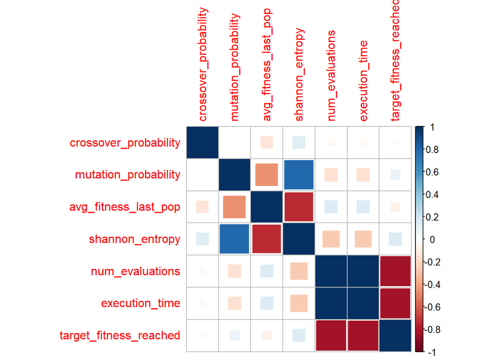

```r
corrplot(corr, method = "square")
```

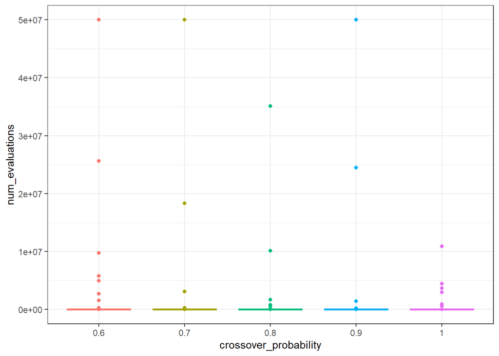

```r
df_study2_large_relaxed %>%
    mutate(crossover_probability = as.factor(crossover_probability)) %>%
    group_by(crossover_probability) %>%
    ggplot(mapping = aes(x = crossover_probability, y = num_evaluations, color=crossover_probability)) +
        geom_boxplot() +
        theme_bw() +
        theme(legend.position = "none")
```

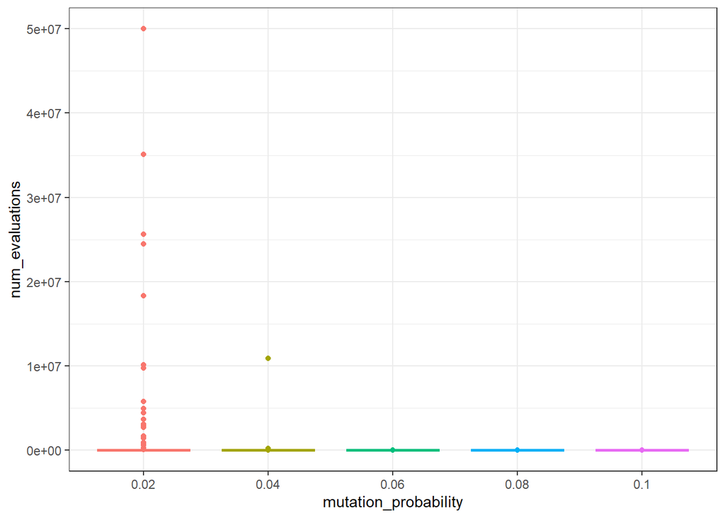

```r
df_study2_large_relaxed %>%
    mutate(mutation_probability = as.factor(mutation_probability)) %>%
    group_by(mutation_probability) %>%
    ggplot(mapping = aes(x = mutation_probability, y = num_evaluations, color=mutation_probability)) +
        geom_boxplot() +
        theme_bw() +
        theme(legend.position = "none")
```